# EBS Pollock RTMB Implementation

# 1 Overview

This document summarizes the RTMB implementation of the EBS pollock ADMB bridge model in this standalone source repository. It follows the same assessment-reporting framework used by the FIMS, SPoRC, and Rceattle implementation documents, but reads the RTMB report object written by `Rscript R/write_output.R`.

The current RTMB implementation should be interpreted as an ADMB-port bridge rather than a self-contained assessment package. It uses the dedicated ADMB bridge run in `admb/runs/for_rtmb/` for initialization and comparison. By default, this report reads the saved RTMB output at `analysis/output/base.rds`, which was created from the ADMB bridge `pm.rep` and `pm.par` files.

# 2 Data Inputs

The RTMB input series include annual fishery catch, fishery age compositions, BTS and ATS age compositions, BTS and ATS survey biomass or abundance indices, acoustic vessels of opportunity, and fishery CPUE. The input data and bridge ADMB output are resolved through `R/config.R` using the external pollock workspace supplied by `POLLOCK_ROOT`.

```r
summary_tbl <- tibble(
  item = c(
    "Years",
    "Ages",
    "Fishery age-composition years",
    "BTS index years",
    "ATS index years",
    "CPUE years",
    "AVO years",
    "Saved RTMB output"
  ),
  value = c(
    paste0(first_year, "-", terminal_year, " (", length(years), ")"),
    paste0(min(ages), "-", max(ages), " (", length(ages), ")"),
    paste0(min(data$yrs_fsh_data), "-", max(data$yrs_fsh_data), " (", length(data$yrs_fsh_data), ")"),
    paste0(min(data$yrs_bts_data), "-", max(data$yrs_bts_data), " (", length(data$yrs_bts_data), ")"),
    paste0(min(data$yrs_ats_data), "-", max(data$yrs_ats_data), " (", length(data$yrs_ats_data), ")"),
    paste0(min(data$yrs_cpue), "-", max(data$yrs_cpue), " (", length(data$yrs_cpue), ")"),
    paste0(min(data$yrs_avo), "-", max(data$yrs_avo), " (", length(data$yrs_avo), ")"),
    params$model_file
  )
)

summary_tbl |>
  gt_report() |>
  tab_header(title = "RTMB-ADMB Input Summary")
```

Table 1: Summary of the EBS pollock RTMB-ADMB input data.

RTMB-ADMB Input Summary

| item | value |
| --- | --- |
| Years | 1964-2024 (61) |
| Ages | 1-15 (15) |
| Fishery age-composition years | 1964-2023 (60) |
| BTS index years | 1982-2024 (42) |
| ATS index years | 1994-2024 (19) |
| CPUE years | 1965-1976 (12) |
| AVO years | 2006-2024 (18) |
| Saved RTMB output | analysis/output/base.rds |

```r
availability <- bind_rows(
  tibble(name = "Fishery", type = "catch", year = years),
  tibble(name = "Fishery", type = "age_comp", year = data$yrs_fsh_data),
  tibble(name = "BTS", type = "index", year = data$yrs_bts_data),
  tibble(name = "BTS", type = "age_comp", year = data$yrs_bts_data),
  tibble(name = "ATS", type = "index", year = data$yrs_ats_data),
  tibble(name = "ATS", type = "age_comp", year = data$yrs_ats_data),
  tibble(name = "CPUE", type = "index", year = data$yrs_cpue),
  tibble(name = "AVO", type = "index", year = data$yrs_avo)
) |>
  group_by(name, type) |>
  summarize(
    n_obs = n(),
    years = paste0(min(year, na.rm = TRUE), "-", max(year, na.rm = TRUE)),
    .groups = "drop"
  ) |>
  arrange(type, name)

availability |>
  gt_report() |>
  tab_header(title = "Data Availability by Fleet")
```

Table 2: Available observations by fleet and data type.

Data Availability by Fleet

| name | type | n_obs | years |
| --- | --- | --- | --- |
| ATS | age_comp | 19 | 1994-2024 |
| BTS | age_comp | 42 | 1982-2024 |
| Fishery | age_comp | 60 | 1964-2023 |
| Fishery | catch | 61 | 1964-2024 |
| ATS | index | 19 | 1994-2024 |
| AVO | index | 18 | 2006-2024 |
| BTS | index | 42 | 1982-2024 |
| CPUE | index | 12 | 1965-1976 |

```r
bridge_file_paths <- c(rtmb_metadata$admb_rep, rtmb_metadata$admb_par, pollock_file("admb", "runs", "for_rtmb", "pm.tpl"))
bridge_files <- tibble(
  file = display_path(bridge_file_paths),
  role = c("ADMB report used for comparison", "ADMB parameter file used for initialization", "ADMB bridge template"),
  exists = file.exists(bridge_file_paths),
  size_kb = round(file.info(bridge_file_paths)$size / 1024, 1),
  modified = as.POSIXct(file.info(bridge_file_paths)$mtime)
)

bridge_files |>
  gt_report() |>
  fmt_number(columns = size_kb, decimals = 1) |>
  tab_header(title = "ADMB Bridge Files")
```

Table 3: ADMB bridge files used by the RTMB implementation.

ADMB Bridge Files

| file | role | exists | size_kb | modified |
| --- | --- | --- | --- | --- |
| [repo]/admb/runs/for_rtmb/pm.rep | ADMB report used for comparison | TRUE | 157.6 | 2026-08-04 23:09:12.450719 |
| [repo]/admb/runs/for_rtmb/pm.par | ADMB parameter file used for initialization | TRUE | 32.0 | 2026-08-04 23:09:12.44994 |
| [repo]/admb/runs/for_rtmb/pm.tpl | ADMB bridge template | TRUE | 279.3 | 2026-06-08 13:33:58.029927 |

# 3 Model Implementation

## 3.1 Structure

- **Population**: single EBS pollock stock.
- **Model engine**: RTMB with the negative log-likelihood written in R.
- **Reference model**: ADMB bridge run in `admb/runs/for_rtmb/`.
- **Fleets and indices**: fishery catch, fishery CPUE, BTS, ATS, and AVO.
- **Age compositions**: fishery, BTS, and ATS age-composition likelihoods.
- **Recruitment**: ADMB-port recruitment likelihood and deviations.
- **Natural mortality**: age-specific input vector from the ADMB bridge data.
- **Selectivity**: fishery, BTS, and ATS selectivity blocks ported from the ADMB bridge configuration.

## 3.2 BTS Selectivity Variation and Penalties

The bottom trawl survey (BTS) selectivity in the RTMB bridge is represented as a time-varying logistic curve for ages 2 and older, with a separate age-1 term. For BTS year (t) and model age (a), the code uses the age midpoint (x_a = a + 0.5) and computes

$$\log s_{t,a}^{\mathrm{BTS}}
= -\log\left[
1 + \exp\left\{-\exp(\gamma_t)\left(x_a - \exp(\alpha_t)\right)\right\}
\right],$$

where $\gamma_t$ is the annual log-slope parameter (`sel_slp_bts_dev`) and $\alpha_t$ is the annual log-age-at-50% parameter (`sel_a50_bts_dev`). Thus the realized slope is $\exp(\gamma_t)$, and the realized age-at-50% is $\exp(\alpha_t)$. Age 1 is then overwritten by its own annual log-selectivity term:

$$\log s_{t,1}^{\mathrm{BTS}} = \eta_t,$$

where $\eta_t$ is `sel_age_one_bts_dev`.

The current RTMB call treats `sel_slp_bts_dev`, `sel_a50_bts_dev`, and `sel_age_one_bts_dev` as estimated annual vectors. The base logistic BTS terms `sel_slp_bts`, `sel_a50_bts`, `sel_age_one_bts`, and `sel_devs_bts` are fixed in `R/config.R`; the time variation is carried by the annual deviation vectors above.

The regularization is applied to the implied annual log-selectivity curves, not directly to $\alpha_t$ or $\gamma_t$. In `selectivity_like_bts()`, an extended matrix $\tilde{\ell}_{t,a}$ is formed by prepending a zero row for the year before the BTS time series. Let $\Delta_t z_t = z_t - z_{t-1}$. The BTS time-variation penalty for ages $a = q_{\min}, \ldots, q_{\max}-1$ is

$$P_{\mathrm{BTS,time}}
= \lambda_{\mathrm{BTS}}
\sum_{a=q_{\min}}^{q_{\max}-1}
\sum_t
\left(\Delta_t \tilde{\ell}_{t,a}\right)^2,$$

where $\lambda_{\mathrm{BTS}}$ is `selVarbts`. In this configuration, `q_amin = 3`, `q_amax` defaults to `nages`, and `nages = 15`, so this penalty applies to ages 3 through 14. Age 2 is not included in this time-smoothness sum, and age 15 is not directly included because the loop stops at `q_amax - 1`.

The age-1 BTS term has a separate first-difference penalty:

$$P_{\mathrm{BTS,age1}}
= 8
\sum_t
\left[
\Delta_t\left(\eta_t - \bar{\eta}\right)
\right]^2,$$

where $\bar{\eta}$ is the mean of the age-1 deviation vector. The total BTS selectivity regularization returned by `selectivity_like_bts()` is

$$P_{\mathrm{BTS}}
= P_{\mathrm{BTS,time}} + P_{\mathrm{BTS,age1}},$$

with no additional BTS curvature penalty active under the current logistic-deviation parameterization.

```r
bts_sel_tbl <- tibble(
  item = c(
    "BTS selectivity start year",
    "Terminal year",
    "Number of annual BTS selectivity years",
    "Estimated annual slope vector",
    "Estimated annual age-at-50 vector",
    "Estimated annual age-1 vector",
    "Time-smoothness weight (`selVarbts`)",
    "Time-smoothness age range",
    "Age-1 first-difference weight",
    "Inactive base BTS terms fixed in config"
  ),
  value = c(
    as.character(data$styr_bts),
    as.character(data$endyr),
    as.character(data$endyr - data$styr_bts + 1),
    "sel_slp_bts_dev",
    "sel_a50_bts_dev",
    "sel_age_one_bts_dev",
    as.character(data$selVarbts),
    paste0(data$q_amin, "-", data$nages - 1),
    "8",
    "sel_devs_bts, sel_slp_bts, sel_a50_bts, sel_age_one_bts"
  )
)

bts_sel_tbl |>
  gt_report() |>
  tab_header(title = "BTS Selectivity Regularization")
```

Table 4: BTS selectivity variation and regularization settings in the current RTMB-ADMB configuration.

BTS Selectivity Regularization

| item | value |
| --- | --- |
| BTS selectivity start year | 1982 |
| Terminal year | 2024 |
| Number of annual BTS selectivity years | 43 |
| Estimated annual slope vector | sel_slp_bts_dev |
| Estimated annual age-at-50 vector | sel_a50_bts_dev |
| Estimated annual age-1 vector | sel_age_one_bts_dev |
| Time-smoothness weight (`selVarbts`) | 2 |
| Time-smoothness age range | 3-14 |
| Age-1 first-difference weight | 8 |
| Inactive base BTS terms fixed in config | sel_devs_bts, sel_slp_bts, sel_a50_bts, sel_age_one_bts |

## 3.3 Run Definitions

The current report has one saved RTMB run, `base`, written by `R/write_output.R`. Refitting can be enabled at render time with `params$refit: true`, but the default render reads the saved RTMB report object to avoid rerunning the optimizer.

```r
run_tbl <- tibble(
  run = "base",
  source = params$model_file,
  refit_default = params$refit,
  output_available = file.exists(model_file),
  report_elements = length(names(rtmb_report)),
  created = as.character(rtmb_metadata$created %||% NA_character_)
)

run_tbl |>
  gt_report() |>
  tab_header(title = "RTMB-ADMB Run Definitions")
```

Table 5: Configured RTMB-ADMB run definitions.

RTMB-ADMB Run Definitions

| run | source | refit_default | output_available | report_elements | created |
| --- | --- | --- | --- | --- | --- |
| base | analysis/output/base.rds | FALSE | TRUE | 42 | 2026-08-05 22:41:21.34062 |

The base output writer follows this pattern.

**Show RTMB output-generation call**

```r
source("R/config.R")
data$return_nll_only <- 0
rtmb_result <- rpm(parms)
saveRDS(
  list(report = rtmb_result$rtmb, metadata = list(model = "rtmb_ebswp")),
  "analysis/output/base.rds"
)
```

# 4 Bridging ADMB to RTMB

This is the same fixed-parameter bridge demonstrated in the September 2025 [EBS pollock development report](https://noaa-afsc.github.io/EBS_pollock/doc/Sept_2025.html#bridging-admb-to-rtmb). The modified ADMB model’s maximum-likelihood parameter estimates are injected into RTMB, and the two implementations are evaluated at that identical parameter point. This isolates the code translation from optimization behavior or later model alternatives.

The refreshed `base.rds` is the authoritative starting point for every result below. Its configuration label, bridge statistics, and file identity are carried into the projections, retrospectives, and SparseNUTS metadata so those analyses cannot silently use a different selectivity form or an older base run.

```r
bridge_metrics <- rtmb_metadata$bridge_metrics
tibble(
  measure = c(
    "ADMB total negative log-likelihood",
    "RTMB total negative log-likelihood",
    "Absolute total NLL difference",
    "Maximum key-output difference (%)",
    "Maximum absolute RTMB gradient"
  ),
  value = c(
    bridge_metrics$admb_total_nll,
    bridge_metrics$rtmb_total_nll,
    bridge_metrics$absolute_total_nll_difference,
    bridge_metrics$maximum_key_percent_difference,
    bridge_metrics$maximum_absolute_gradient
  )
) |>
  gt_report() |>
  fmt_number(columns = value, decimals = 9) |>
  tab_header(title = "September 2025 ADMB–RTMB Bridge")
```

Table 6: Summary of the fixed-parameter ADMB-to-RTMB bridge, recalculated from the September 2025 configuration. The absolute NLL difference is on the negative-log-likelihood scale; the key-output difference is the largest absolute percentage difference among state, prediction, selectivity, composition, and likelihood quantities.

September 2025 ADMB–RTMB Bridge

| measure | value |
| --- | --- |
| ADMB total negative log-likelihood | 7,940.720000000 |
| RTMB total negative log-likelihood | 7,940.715902252 |
| Absolute total NLL difference | 0.004097748 |
| Maximum key-output difference (%) | 0.000492728 |
| Maximum absolute RTMB gradient | 0.000006365 |

The total negative log-likelihoods differ by only 0.004097748. The maximum difference among key outputs is 0.000492728%, and the largest absolute RTMB gradient at the ADMB estimates is 6.36535e-06. These reproduce the near-perfect September bridge and pass the repository’s automated bridge tolerances.

```r
current_base_md5 <- unname(tools::md5sum(model_file))
projection_lineage <- readr::read_csv(
  file.path(projection_dir, "base_lineage.csv"), show_col_types = FALSE
)
alt2_lineage <- readr::read_csv(
  file.path(projection_alt2_dir, "base_lineage.csv"), show_col_types = FALSE
)
mcmc_lineage <- readr::read_csv(
  rtmb_file("reporting", "data", "sparsenuts_base_run_summary.csv"),
  show_col_types = FALSE
)
lineage_tbl <- tibble(
  analysis = c(
    "Authoritative base bridge", "Nine-peel retrospective",
    "Seven-scenario Tier 3 projections", "Alternative 2 fixed-catch projections",
    "SparseNUTS MCMC"
  ),
  base_md5 = c(
    current_base_md5,
    retro_saved$base_lineage$md5 %||% NA_character_,
    projection_lineage$model_md5[1] %||% NA_character_,
    alt2_lineage$model_md5[1] %||% NA_character_,
    mcmc_lineage$base_md5[1] %||% NA_character_
  )
) |>
  mutate(matches_authoritative_base = base_md5 == current_base_md5)

lineage_tbl |>
  gt_report() |>
  tab_header(title = "Common September-Bridge Lineage")
```

Table 7: Base-model lineage for downstream analyses. Matching checksums confirm that projections, retrospectives, and SparseNUTS were regenerated from the same refreshed September 2025 bridge output.

Common September-Bridge Lineage

| analysis | base_md5 | matches_authoritative_base |
| --- | --- | --- |
| Authoritative base bridge | ae049e9e07d77c5dee6df300bc3ae09d | TRUE |
| Nine-peel retrospective | ae049e9e07d77c5dee6df300bc3ae09d | TRUE |
| Seven-scenario Tier 3 projections | ae049e9e07d77c5dee6df300bc3ae09d | TRUE |
| Alternative 2 fixed-catch projections | ae049e9e07d77c5dee6df300bc3ae09d | TRUE |
| SparseNUTS MCMC | ae049e9e07d77c5dee6df300bc3ae09d | TRUE |

```r
rtmb_bridge_comparison |>
  filter(is.finite(max_abs_diff) | !is.na(equal)) |>
  arrange(desc(max_abs_pct_diff)) |>
  rename(
    Quantity = variable,
    Equal = equal,
    Elements = length,
    `Maximum absolute difference` = max_abs_diff,
    `Maximum absolute difference (%)` = max_abs_pct_diff,
    Correlation = cor
  ) |>
  gt_report() |>
  fmt_number(
    columns = c(
      `Maximum absolute difference`,
      `Maximum absolute difference (%)`, Correlation
    ),
    decimals = 7
  ) |>
  tab_header(title = "RTMB and ADMB Object Comparison")
```

Table 8: Object-by-object comparison of RTMB and ADMB results at the shared ADMB maximum-likelihood parameter point. `Equal` is the result of the numerical comparison at tolerance 1e-5; correlation is shown for compatible nonconstant vectors.

RTMB and ADMB Object Comparison

| Quantity | Equal | Elements | Maximum absolute difference | Maximum absolute difference (%) | Correlation |
| --- | --- | --- | --- | --- | --- |
| sel_fsh | TRUE | 915 | 0.0000050 | 0.0004927 | 1.0000000 |
| N | TRUE | 915 | 0.0499186 | 0.0004863 | 1.0000000 |
| F | TRUE | 915 | 0.0000005 | 0.0004824 | 1.0000000 |
| phat_fsh | TRUE | 900 | 0.0000005 | 0.0004822 | 1.0000000 |
| sel_ats | TRUE | 465 | 0.0000050 | 0.0004714 | 1.0000000 |
| phat_bts | TRUE | 630 | 0.0000005 | 0.0004692 | 1.0000000 |
| obs_catch | TRUE | 61 | 0.0050000 | 0.0004579 | 1.0000000 |
| eb_bts | TRUE | 42 | 0.0487113 | 0.0004556 | 1.0000000 |
| SSB | TRUE | 61 | 0.0049551 | 0.0004471 | 1.0000000 |
| phat_ats | TRUE | 285 | 0.0048554 | 0.0004432 | 1.0000000 |
| pred_avo | TRUE | 18 | 0.0000048 | 0.0004090 | 1.0000000 |
| sel_bts | TRUE | 645 | 0.0000005 | 0.0004004 | 1.0000000 |
| pred_catch | TRUE | 61 | 0.0049711 | 0.0003830 | 1.0000000 |
| sel_like_dev | TRUE | 3 | 0.0004644 | 0.0003750 | 1.0000000 |
| age_like_offset | TRUE | 3 | 0.0394958 | 0.0003259 | 1.0000000 |
| cpue_like | TRUE | 1 | 0.0000029 | 0.0002644 | NA |
| eb_ats | TRUE | 19 | 0.0048630 | 0.0002436 | 1.0000000 |
| ats_age1_like | TRUE | 1 | 0.0000242 | 0.0002163 | NA |
| age_like | TRUE | 3 | 0.0010474 | 0.0001985 | 1.0000000 |
| rec_like | TRUE | 7 | 0.0000424 | 0.0001965 | 1.0000000 |
| phizero | TRUE | 1 | 0.0000005 | 0.0001886 | NA |
| wt_nll | TRUE | 4 | 0.0041163 | 0.0001671 | 1.0000000 |
| Z | TRUE | 915 | 0.0000005 | 0.0001609 | 1.0000000 |
| pred_cpue | TRUE | 12 | 0.0045862 | 0.0001461 | 1.0000000 |
| sam_fsh | TRUE | 60 | 0.0004988 | 0.0001344 | 1.0000000 |
| sel_like | TRUE | 3 | 0.0000208 | 0.0001235 | 1.0000000 |
| S | TRUE | 915 | 0.0000005 | 0.0001225 | 1.0000000 |
| Priors | TRUE | 4 | 0.0000237 | 0.0001177 | 1.0000000 |
| wt_like | TRUE | 1 | 0.0048053 | 0.0000757 | NA |
| avgsel_like | TRUE | 1 | 0.0000001 | 0.0000606 | NA |
| cat_like | TRUE | 1 | 0.0000016 | 0.0000572 | NA |
| tot_like | TRUE | 1 | 0.0040977 | 0.0000516 | NA |
| steepness | TRUE | 1 | 0.0000003 | 0.0000506 | NA |
| bts_like | TRUE | 1 | 0.0000144 | 0.0000434 | NA |
| Bzero | TRUE | 1 | 0.0024093 | 0.0000394 | NA |
| ats_like | TRUE | 1 | 0.0000018 | 0.0000193 | NA |
| Fpen_like | TRUE | 1 | 0.0000014 | 0.0000145 | NA |
| avo_like | TRUE | 1 | 0.0000004 | 0.0000044 | NA |
| M | TRUE | 915 | 0.0000000 | 0.0000000 | 1.0000000 |
| sam_bts | TRUE | 42 | 0.0000000 | 0.0000000 | 1.0000000 |
| sam_ats | TRUE | 19 | 0.0000000 | 0.0000000 | 1.0000000 |

```r
tibble(
  parameter = names(obj$par),
  gradient = as.numeric(obj$gr())
) |>
  mutate(absolute_gradient = abs(gradient)) |>
  arrange(desc(absolute_gradient)) |>
  slice_head(n = 20) |>
  select(parameter, gradient, absolute_gradient) |>
  gt_report() |>
  fmt_scientific(columns = c(gradient, absolute_gradient), decimals = 4) |>
  tab_header(title = "Largest RTMB Gradients at ADMB Estimates")
```

```
outer mgc:  6.36535e-06
```

Table 9: Twenty largest RTMB gradients at the ADMB maximum-likelihood parameter estimates. Values close to zero confirm that the injected ADMB solution is also stationary in RTMB.

Largest RTMB Gradients at ADMB Estimates

| parameter | gradient | absolute_gradient |
| --- | --- | --- |
| sel_slp_bts_dev | 6.3653 × 10<sup>−6</sup> | 6.3653 × 10<sup>−6</sup> |
| sel_devs_ats | −5.1508 × 10<sup>−6</sup> | 5.1508 × 10<sup>−6</sup> |
| sel_age_one_bts_dev | 4.9800 × 10<sup>−6</sup> | 4.9800 × 10<sup>−6</sup> |
| sel_devs_ats | 4.8539 × 10<sup>−6</sup> | 4.8539 × 10<sup>−6</sup> |
| sel_age_one_bts_dev | −4.4870 × 10<sup>−6</sup> | 4.4870 × 10<sup>−6</sup> |
| sel_slp_bts_dev | −4.4021 × 10<sup>−6</sup> | 4.4021 × 10<sup>−6</sup> |
| sel_devs_ats | 4.1613 × 10<sup>−6</sup> | 4.1613 × 10<sup>−6</sup> |
| sel_age_one_bts_dev | 4.1383 × 10<sup>−6</sup> | 4.1383 × 10<sup>−6</sup> |
| sel_devs_ats | −4.1011 × 10<sup>−6</sup> | 4.1011 × 10<sup>−6</sup> |
| sel_devs_ats | −4.0973 × 10<sup>−6</sup> | 4.0973 × 10<sup>−6</sup> |
| sel_slp_bts_dev | 3.4871 × 10<sup>−6</sup> | 3.4871 × 10<sup>−6</sup> |
| sel_slp_bts_dev | 3.2583 × 10<sup>−6</sup> | 3.2583 × 10<sup>−6</sup> |
| sel_devs_ats | 3.1944 × 10<sup>−6</sup> | 3.1944 × 10<sup>−6</sup> |
| sel_devs_ats | −3.1906 × 10<sup>−6</sup> | 3.1906 × 10<sup>−6</sup> |
| sel_devs_ats | 3.1462 × 10<sup>−6</sup> | 3.1462 × 10<sup>−6</sup> |
| sel_devs_ats | 3.0688 × 10<sup>−6</sup> | 3.0688 × 10<sup>−6</sup> |
| sel_devs_ats | 3.0087 × 10<sup>−6</sup> | 3.0087 × 10<sup>−6</sup> |
| sel_devs_ats | 2.9636 × 10<sup>−6</sup> | 2.9636 × 10<sup>−6</sup> |
| sel_age_one_bts_dev | 2.9621 × 10<sup>−6</sup> | 2.9621 × 10<sup>−6</sup> |
| sel_devs_ats | 2.9526 × 10<sup>−6</sup> | 2.9526 × 10<sup>−6</sup> |

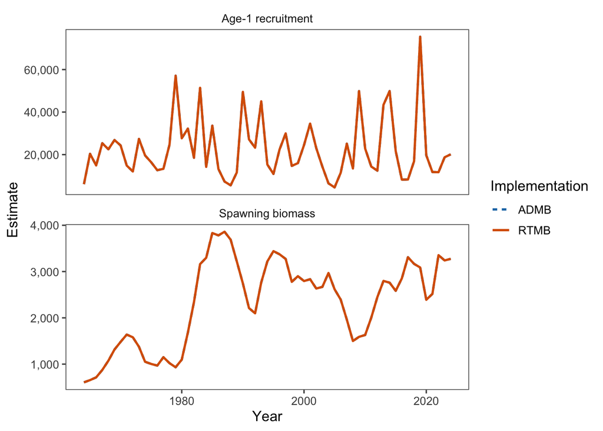

Figure 1: Spawning biomass and age-1 recruitment from RTMB and ADMB at the same ADMB maximum-likelihood parameter estimates. The two implementations are visually indistinguishable at the plotted scale. Select the figure to open it in the lightbox.

```r
bridge_years <- data$styr:data$endyr
bridge_series <- bind_rows(
  tibble(
    year = bridge_years,
    quantity = "Spawning biomass",
    model = "RTMB",
    value = as.numeric(rtmb_report$SSB)
  ),
  tibble(
    year = bridge_years,
    quantity = "Spawning biomass",
    model = "ADMB",
    value = as.numeric(pm$SSB)
  ),
  tibble(
    year = bridge_years,
    quantity = "Age-1 recruitment",
    model = "RTMB",
    value = as.numeric(rtmb_report$N[, 1])
  ),
  tibble(
    year = bridge_years,
    quantity = "Age-1 recruitment",
    model = "ADMB",
    value = as.numeric(pm$N[, 1])
  )
)

ggplot(bridge_series, aes(year, value, color = model, linetype = model)) +
  geom_line(linewidth = 0.9) +
  facet_wrap(~quantity, scales = "free_y", ncol = 1) +
  scale_color_manual(values = c(ADMB = "#1f78b4", RTMB = "#d95f02")) +
  scale_linetype_manual(values = c(ADMB = "22", RTMB = "solid")) +
  scale_y_continuous(labels = scales::label_comma()) +
  labs(x = "Year", y = "Estimate", color = "Implementation", linetype = "Implementation")
```

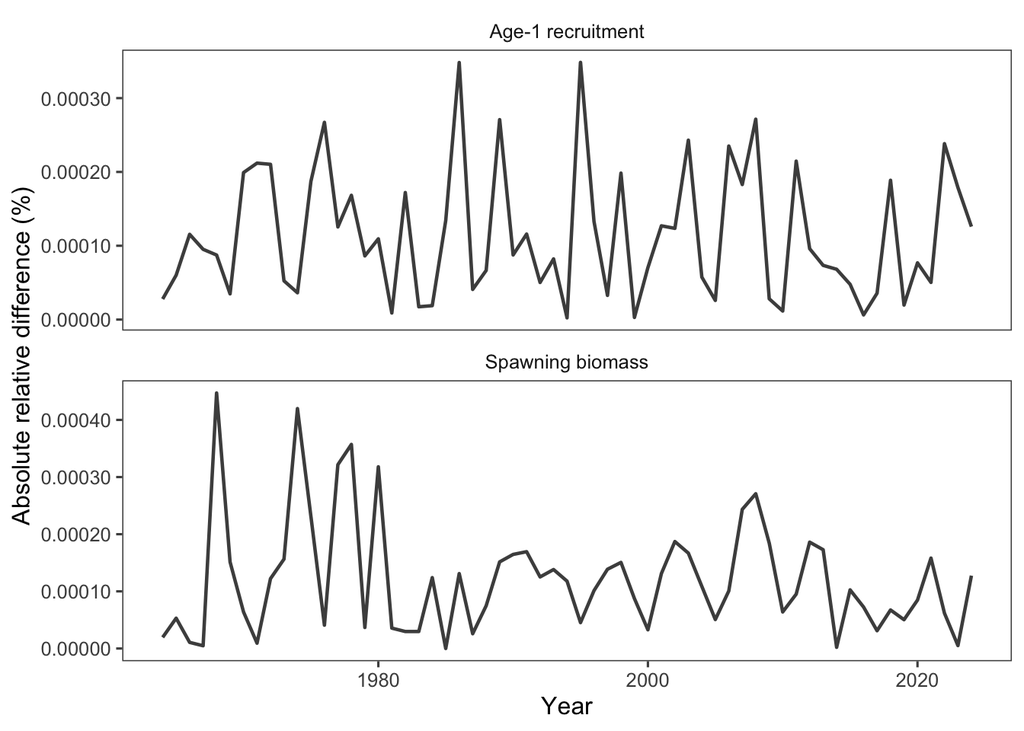

Figure 2: Absolute relative differences between RTMB and ADMB spawning biomass and age-1 recruitment at the shared ADMB estimates. Values are percentages; the very small vertical scale is intentional. Select the figure to open it in the lightbox.

```r
bridge_difference <- bridge_series |>
  pivot_wider(names_from = model, values_from = value) |>
  mutate(
    absolute_relative_difference =
      100 * abs(RTMB - ADMB) / pmax(abs(ADMB), .Machine$double.eps)
  )

ggplot(bridge_difference, aes(year, absolute_relative_difference)) +
  geom_line(color = "#4d4d4d", linewidth = 0.8) +
  facet_wrap(~quantity, scales = "free_y", ncol = 1) +
  scale_y_continuous(labels = scales::label_number(accuracy = 0.00001)) +
  labs(x = "Year", y = "Absolute relative difference (%)")
```

# 5 Results

## 5.1 Fit to Base RTMB-ADMB Run

The current fitted results are for the saved RTMB-ADMB `base` run. The fitted spawning biomass trajectory is shown in Figure 3. Fishery observed and predicted catch are compared in Figure 4, while survey, CPUE, and AVO index fits are summarized in Figure 5 and residual patterns are shown in Figure 6. Expected age-composition outputs for fishery, BTS, and ATS are shown in Figure 7, Figure 8, and Figure 9. Fleet selectivity curves are shown in Figure 11. Diagnostics and bridge comparisons are reported in Table 19, Table 20, Table 24, and Figure 19.

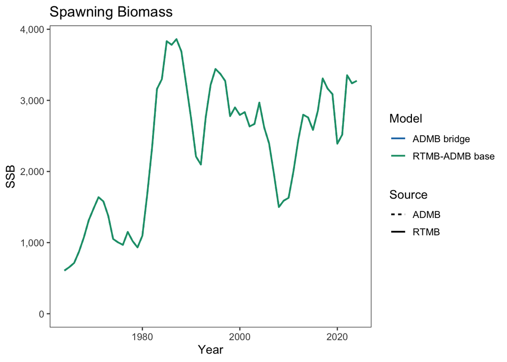

Figure 3: Estimated spawning biomass from the saved EBS pollock RTMB-ADMB base model, with the ADMB bridge output overlaid when available.

```r
ssb_overlay <- bind_rows(
  ts_df |>
    transmute(model = "RTMB-ADMB base", source = "RTMB", year, value = ssb),
  admb_ts |>
    filter(quantity == "SSB") |>
    transmute(model, source, year, value)
)

ggplot(ssb_overlay, aes(x = year, y = value, color = model, linetype = source)) +
  geom_line(linewidth = 0.8) +
  scale_y_continuous(limits = c(0, NA), labels = scales::label_comma()) +
  scale_color_manual(values = c("RTMB-ADMB base" = "#1b9e77", "ADMB bridge" = "#1f78b4")) +
  scale_linetype_manual(values = c("RTMB" = "solid", "ADMB" = "22")) +
  labs(x = "Year", y = "SSB", color = "Model", linetype = "Source", title = "Spawning Biomass")
```

### 5.1.1 Catch Fit

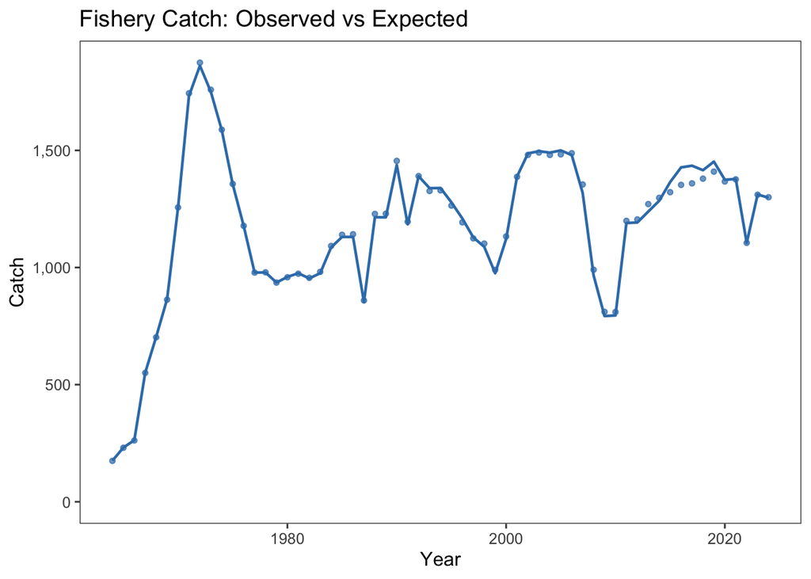

Figure 4: Observed fishery catch and predicted catch from the saved RTMB-ADMB model.

```r
ggplot(catch_df, aes(x = year)) +
  geom_line(aes(y = expected), color = "#377eb8", linewidth = 0.8) +
  geom_point(aes(y = observed), color = "#377eb8", size = 1.2, alpha = 0.7) +
  scale_y_continuous(limits = c(0, NA), labels = scales::label_comma()) +
  labs(x = "Year", y = "Catch", title = "Fishery Catch: Observed vs Expected")
```

### 5.1.2 Fits by Fleet

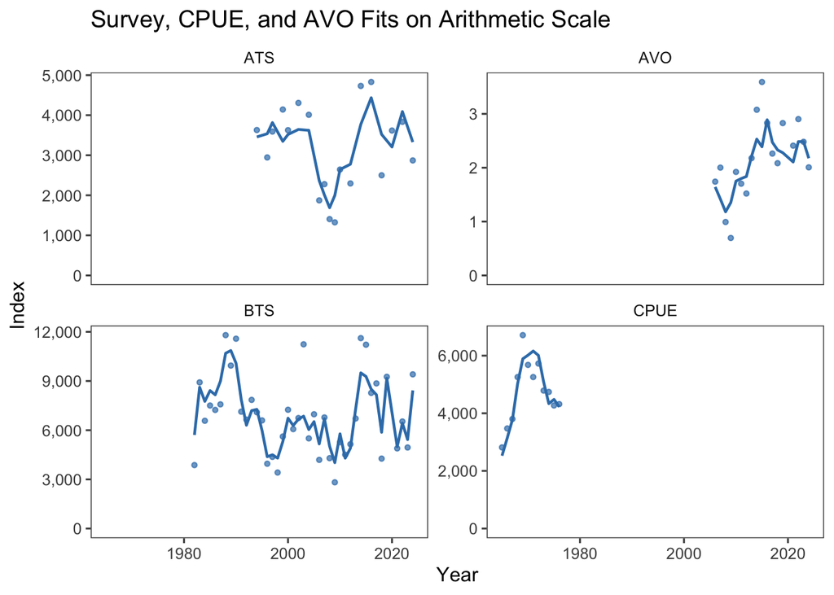

Figure 5: Observed and predicted index series from the saved RTMB-ADMB model, shown on arithmetic scales with separate facet axes.

```r
ggplot(index_df, aes(x = year)) +
  geom_line(aes(y = expected), color = "#377eb8", linewidth = 0.8) +
  geom_point(aes(y = observed), color = "#377eb8", size = 1.1, alpha = 0.7, na.rm = TRUE) +
  facet_wrap(~series, scales = "free_y") +
  scale_y_continuous(limits = c(0, NA), labels = scales::label_comma()) +
  labs(x = "Year", y = "Index", title = "Survey, CPUE, and AVO Fits on Arithmetic Scale")
```

### 5.1.3 Residuals

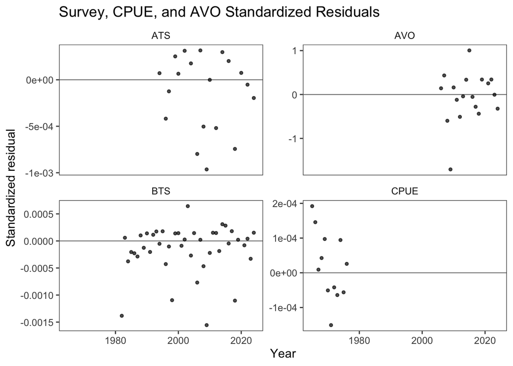

Figure 6: Approximate standardized log residuals for RTMB-ADMB index observations. Residuals are divided by the input log standard deviation.

```r
ggplot(index_df, aes(x = year, y = std_residual)) +
  geom_hline(yintercept = 0, color = "gray50", linewidth = 0.4) +
  geom_point(size = 1.1, alpha = 0.7) +
  facet_wrap(~series, scales = "free_y") +
  labs(x = "Year", y = "Standardized residual", title = "Survey, CPUE, and AVO Standardized Residuals")
```

### 5.1.4 Age Composition Fits

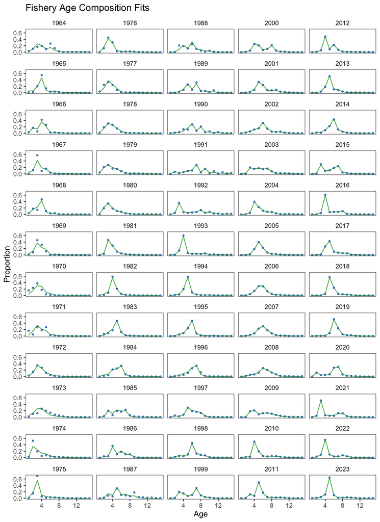

Figure 7: Observed and expected fishery age-composition patterns from the saved RTMB-ADMB model, faceted by year.

```r
plot_agecomp_fit(agecomp_df, "Fishery", ncol = 5)
```

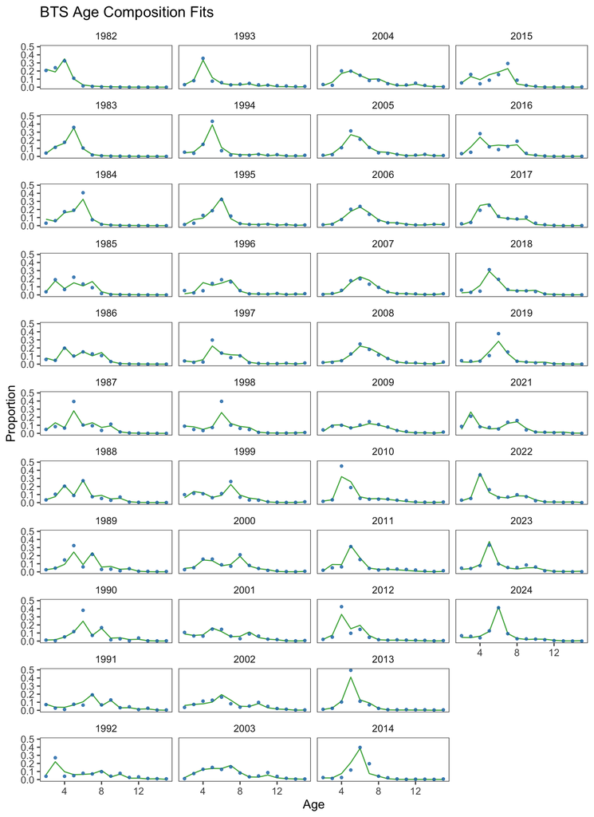

Figure 8: Observed and expected BTS age-composition patterns from the saved RTMB-ADMB model, faceted by year.

```r
plot_agecomp_fit(agecomp_df, "BTS", ncol = 4)
```

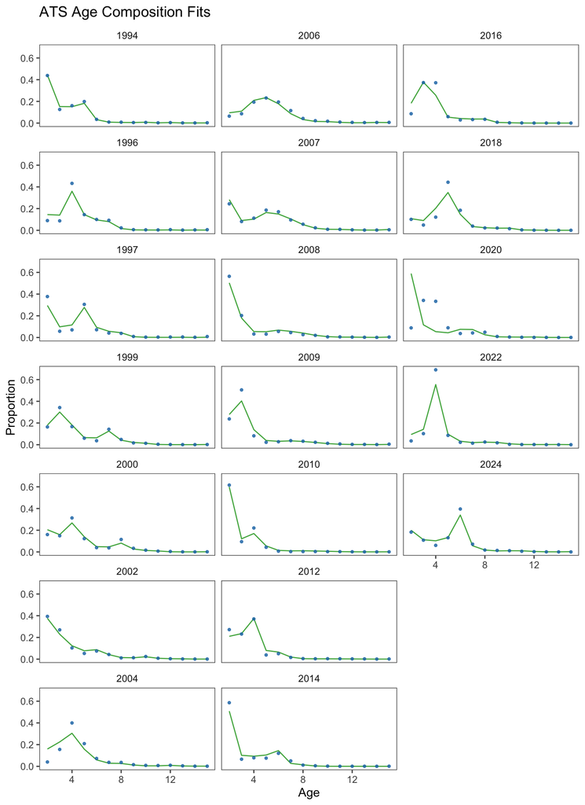

Figure 9: Observed and expected ATS age-composition patterns from the saved RTMB-ADMB model, faceted by year.

```r
plot_agecomp_fit(agecomp_df, "ATS", ncol = 3)
```

### 5.1.5 OSA Residual Diagnostics

The age-composition diagnostics follow the updated [afscOSA guidance](https://noaa-afsc.github.io/afscOSA/) incorporated through [afscOSA pull request 10](https://github.com/noaa-afsc/afscOSA/pull/10). The diagnostics were regenerated from the accepted September 2025 bridge base model rather than from a selectivity sensitivity. In this render, the method is afscOSA 0.1.0 output generated from the accepted RTMB base model.

The four rows in Figure 10 should be read together. The aggregate composition is the first check for systematic lack of fit, such as a selectivity pattern that consistently misses particular ages. The Q-Q plot assesses whether OSA residuals behave approximately as standard normal values and reports the SDNR and lower and upper 2.5% quantiles with their expected intervals. The OSA and Pearson bubble plots then help locate temporal, age-specific, or cohort patterns. A statistic outside its interval is a clue to investigate, not a stand-alone rule for accepting or rejecting an assessment configuration.

```r
tibble(
  item = c(
    "afscOSA version",
    "R version used for OSA calculations",
    "Accepted base-model checksum (MD5)",
    "OSA input checksum (MD5)",
    "Excluded zero-information composition row",
    "Fleets",
    "OSA residuals"
  ),
  value = c(
    if (isTRUE(osa_precomputed_available)) osa_output$afscOSA_version else NA_character_,
    if (isTRUE(osa_precomputed_available)) osa_output$r_version else NA_character_,
    if (isTRUE(osa_precomputed_available)) osa_output$lineage$base_md5 else NA_character_,
    if (isTRUE(osa_precomputed_available)) osa_output$input_md5 else NA_character_,
    if (isTRUE(osa_precomputed_available)) "ATS 2020" else NA_character_,
    paste(sort(unique(diagnostic_residual_df$fleet)), collapse = ", "),
    as.character(nrow(diagnostic_residual_df))
  )
) |>
  gt_report() |>
  tab_header(title = "OSA Diagnostic Source Check")
```

Table 10: Source and software checks for the updated OSA diagnostics. The base-model checksum ties these diagnostics to the same accepted RTMB object used elsewhere in this report. The ATS 2020 placeholder was excluded because it contains no rounded multinomial observations and therefore supplies no information to an OSA calculation.

OSA Diagnostic Source Check

[output not shown]

```r
osa_output$summary |>
  arrange(fleet) |>
  select(
    Fleet = fleet,
    `OSA residuals` = residuals,
    `Mean residual` = mean,
    SDNR = sdnr,
    `Lower 2.5% quantile` = lower_2.5_pct,
    `Upper 97.5% quantile` = upper_97.5_pct
  ) |>
  gt_report() |>
  fmt_number(
    columns = c(`Mean residual`, SDNR, `Lower 2.5% quantile`, `Upper 97.5% quantile`),
    decimals = 2
  ) |>
  fmt_number(columns = `OSA residuals`, decimals = 0) |>
  tab_header(title = "OSA Residual Distribution Summary")
```

Table 11: Summary of one-step-ahead residual distributions. Under a correctly specified composition model, OSA residuals are expected to be approximately standard normal: mean near zero, SDNR near one, and 2.5% tail quantiles near -1.96 and 1.96. Formal expected intervals are shown in the Q-Q panels of Figure Figure 10; these summaries are diagnostic context rather than model-selection tests.

OSA Residual Distribution Summary

| Fleet | OSA residuals | Mean residual | SDNR | Lower 2.5% quantile | Upper 97.5% quantile |
| --- | --- | --- | --- | --- | --- |
| ATS | 234 | 0.07 | 0.82 | −1.81 | 1.66 |
| BTS | 588 | −0.06 | 0.96 | −1.96 | 1.72 |
| Fishery | 840 | −0.06 | 0.87 | −1.92 | 1.61 |

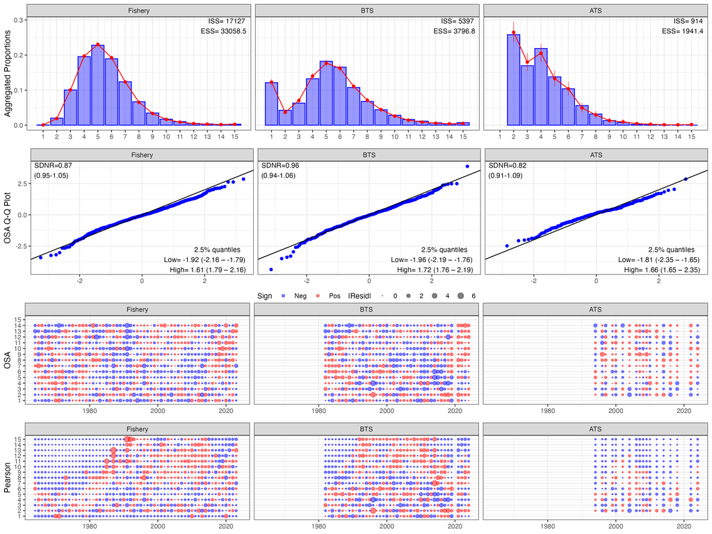

Figure 10: Age-composition diagnostics produced with afscOSA for the fishery, bottom trawl survey (BTS), and acoustic-trawl survey (ATS). Top row: observed aggregate proportions (blue bars), expected proportions (red points and line), and 95% intervals for data expected from the fitted model (red vertical lines); the intervals condition on fitted parameters and are neither confidence intervals nor posterior predictive intervals. ISS and ESS are the aggregate input and effective sample sizes. Second row: OSA residual Q-Q plots with SDNR and 2.5% tail quantiles; parentheses give their expected 95% intervals. Third and fourth rows: OSA and Pearson residual bubbles by year and age, with red positive and blue negative residuals and bubble area increasing with absolute magnitude. Bubble sizes are standardized across fleets; two Pearson residuals greater than 6 were truncated to 6 for display only. The diagnostics should be interpreted jointly and do not constitute a stand-alone model acceptance or rejection test.

```r
knitr::include_graphics(osa_plot_file)
```

The aggregate panels show generally close observed and expected patterns, with localized departures that deserve attention rather than a wholesale failure of the composition model. The BTS SDNR (0.96) lies within its displayed expected interval. Fishery (0.87) and ATS (0.82) have narrower OSA residual distributions than standard normal expectations; this can reflect composition weighting, residual dependence, or other model structure and should be considered alongside the aggregate and bubble patterns. The fishery upper tail is also lighter than expected, while the other tail estimates are close to or within their displayed intervals. These results identify where follow-up work may be useful, but they do not by themselves determine the preferred assessment model.

### 5.1.6 Selectivity Curves

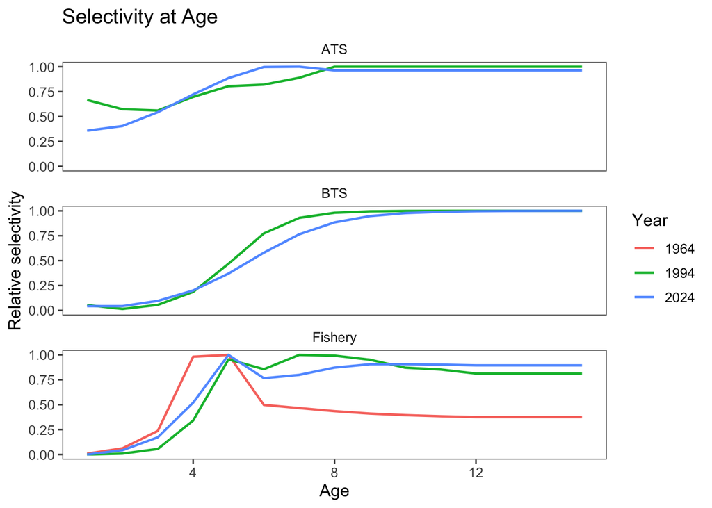

Figure 11: Estimated RTMB-ADMB selectivity-at-age curves by fleet in selected years.

```r
selected_years <- c(first_year, years[ceiling(length(years) / 2)], terminal_year)
sel_df <- bind_rows(
  as_year_age_df(rtmb_report$sel_fsh, years, "Fishery", "selectivity"),
  as_year_age_df(rtmb_report$sel_bts, data$styr_bts:data$endyr, "BTS", "selectivity"),
  as_year_age_df(rtmb_report$sel_ats, data$styr_ats:data$endyr, "ATS", "selectivity")
) |>
  filter(year %in% selected_years | year == min(year) | year == max(year)) |>
  group_by(fleet, year) |>
  mutate(selectivity = selectivity / max(selectivity, na.rm = TRUE)) |>
  ungroup()

ggplot(sel_df, aes(x = age, y = selectivity, color = factor(year))) +
  geom_line(linewidth = 0.8) +
  facet_wrap(~fleet, ncol = 1) +
  scale_y_continuous(limits = c(0, NA)) +
  labs(x = "Age", y = "Relative selectivity", color = "Year", title = "Selectivity at Age")
```

### 5.1.7 Selectivity Ridge Plots

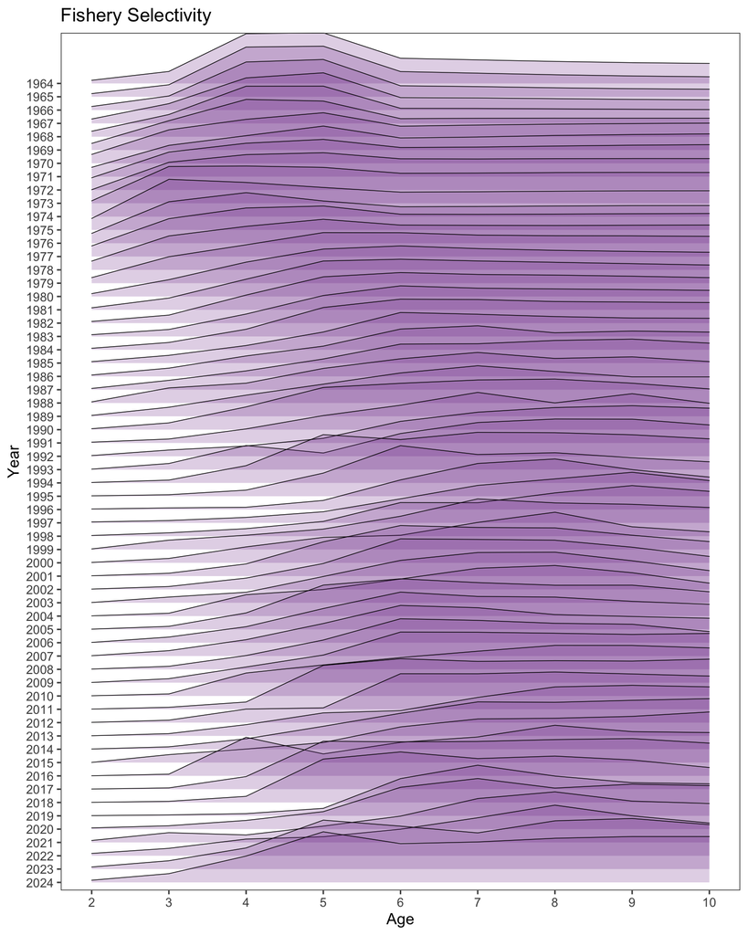

Figure 12: Relative fishery selectivity over time from the RTMB-ADMB model. Ridge heights are normalized within year.

```r
ridge_df <- bind_rows(
  as_year_age_df(rtmb_report$sel_fsh, years, "Fishery", "selectivity"),
  as_year_age_df(rtmb_report$sel_bts, data$styr_bts:data$endyr, "BTS", "selectivity"),
  as_year_age_df(rtmb_report$sel_ats, data$styr_ats:data$endyr, "ATS", "selectivity")
) |>
  filter(age >= 2, age <= 10) |>
  group_by(fleet, year) |>
  mutate(relative_selectivity = selectivity / max(selectivity, na.rm = TRUE)) |>
  ungroup() |>
  mutate(year_factor = factor(year, levels = rev(sort(unique(year)))))

ggplot(ridge_df |> filter(fleet == "Fishery"), aes(x = age, y = year_factor, height = relative_selectivity)) +
  ggridges::geom_density_ridges(
    stat = "identity",
    scale = 3.8,
    alpha = 0.22,
    fill = "#7b3294",
    color = "black",
    linewidth = 0.25
  ) +
  scale_x_continuous(limits = c(2, 10), breaks = 2:10) +
  labs(x = "Age", y = "Year", title = "Fishery Selectivity")
```

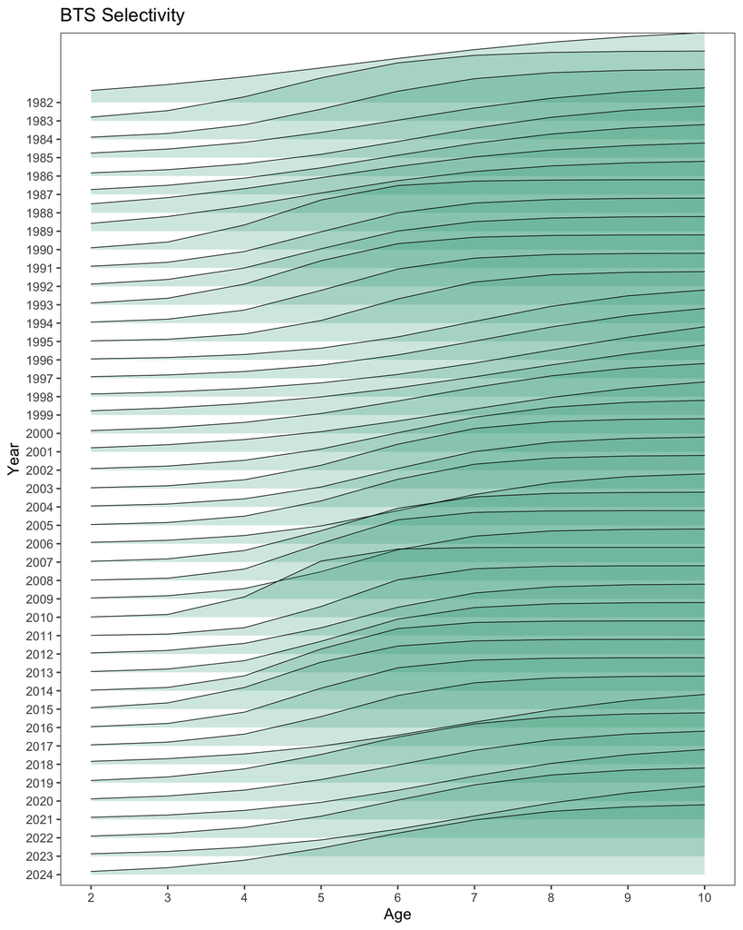

Figure 13: Relative BTS selectivity over time from the RTMB-ADMB model. Ridge heights are normalized within year.

```r
ggplot(ridge_df |> filter(fleet == "BTS"), aes(x = age, y = year_factor, height = relative_selectivity)) +
  ggridges::geom_density_ridges(
    stat = "identity",
    scale = 3.8,
    alpha = 0.22,
    fill = "#1b9e77",
    color = "black",
    linewidth = 0.25
  ) +
  scale_x_continuous(limits = c(2, 10), breaks = 2:10) +
  labs(x = "Age", y = "Year", title = "BTS Selectivity")
```

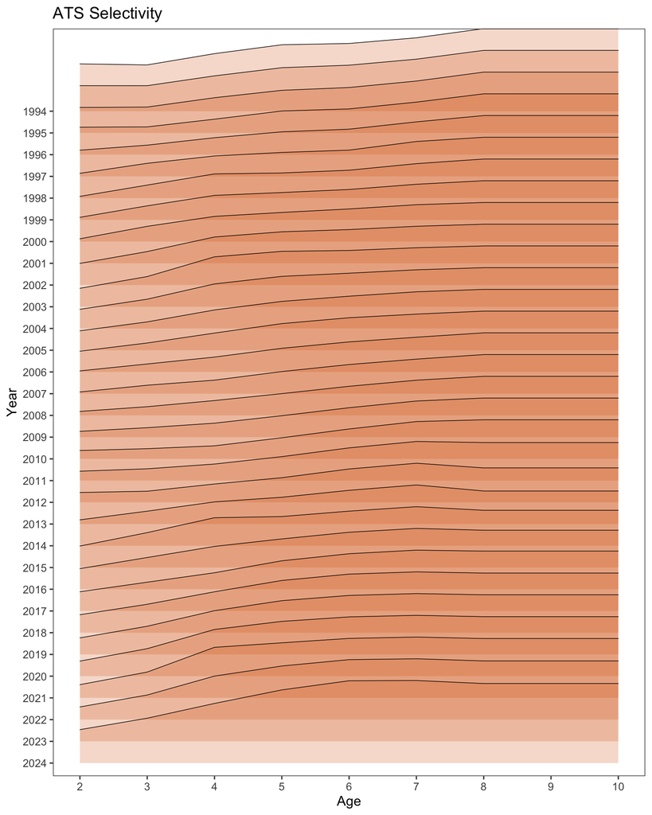

Figure 14: Relative ATS selectivity over time from the RTMB-ADMB model. Ridge heights are normalized within year.

```r
ggplot(ridge_df |> filter(fleet == "ATS"), aes(x = age, y = year_factor, height = relative_selectivity)) +
  ggridges::geom_density_ridges(
    stat = "identity",
    scale = 3.8,
    alpha = 0.22,
    fill = "#d95f02",
    color = "black",
    linewidth = 0.25
  ) +
  scale_x_continuous(limits = c(2, 10), breaks = 2:10) +
  labs(x = "Age", y = "Year", title = "ATS Selectivity")
```

# 6 Projections

The RTMB bridge can now write a Standard Projection Model input directory for use with `spmR`. This report writes the current saved RTMB output to [repo]/analysis/output/spmR_projection, using the same SPM setup structure as the ADMB bridge projection directory while replacing the species assessment input file with an RTMB-derived `pm.prj`.

```r
spmr_manifest |>
  mutate(
    file = basename(file),
    exists = as.character(exists)
  ) |>
  gt_report() |>
  tab_header(title = "spmR Projection Input Files")
```

Table 12: Projection input files written for the spmR/SPM workflow.

spmR Projection Input Files

| file | role | exists |
| --- | --- | --- |
| spm.dat | SPM setup file | TRUE |
| pm.prj | Species assessment input file generated from RTMB | TRUE |
| tacpar.dat | SPM TAC parameter file copied from ADMB bridge projection directory | TRUE |
| spm | SPM executable copied from ADMB bridge projection directory | TRUE |

```r
if (!is.null(spmr_input)) {
  tibble(
    item = c(
      "Projection directory",
      "Projection begin year",
      "Projection years",
      "Simulations",
      "Alternatives",
      "Species input file"
    ),
    value = c(
      display_path(spmr_projection$output_dir),
      as.character(spmr_input$beg_yr %||% spmr_input$styr),
      as.character(spmr_input$nprj_yrs %||% spmr_input$npro),
      as.character(spmr_input$nsims),
      paste(as.integer(spmr_input$alts %||% spmr_input$alt_list), collapse = ", "),
      as.character(spmr_input$datafile %||% spmr_input$spp_file_name)
    )
  ) |>
    gt_report() |>
    tab_header(title = "Generated SPM Setup")
} else {
  tibble(
    item = c("Projection directory", "spmR parser"),
    value = c(display_path(spmr_projection$output_dir), "spmR is not installed in the render environment")
  ) |>
    gt_report() |>
    tab_header(title = "Generated SPM Setup")
}
```

Table 13: Key settings in the generated SPM projection setup file.

Generated SPM Setup

| item | value |
| --- | --- |
| Projection directory | [repo]/analysis/output/spmR_projection |
| spmR parser | spmR is not installed in the render environment |

```r
spmr_alt_desc <- tibble(
  Alternative = 1:7,
  Name = c(
    "Maximum permissible ABC",
    "Author-specified ABC",
    "Average recent F",
    "Alternative SPR rate",
    "No fishing",
    "OFL threshold determination",
    "Status-determination ramp"
  ),
  Description = c(
    "Projects catch using the maximum permissible Tier 3 ABC harvest rate from the SPM harvest-control rule.",
    "Projects catch using the author-specified adjustment to the Tier 3 ABC harvest rate. In this generated RTMB setup, the author-F adjustment and ABC multiplier are both 1.0, so this alternative is currently equivalent to Alternative 1 unless those inputs are changed.",
    "Projects catch using the recent average fishing mortality read from the assessment input file, rather than recalculating catch from the ABC harvest-control rule.",
    "Projects catch using the user-specified Alternative 4 SPR rate. The generated setup uses SPR = 0.60, matching the SPM input convention for this alternative.",
    "Projects the stock forward with F = 0, so catch is zero after any fixed catch years specified in the setup file.",
    "Projects catch at the OFL harvest rate. This alternative is used for threshold/status-determination calculations and is not constrained by the TAC-equals-ABC rule in the same way as the ABC alternatives.",
    "Applies maximum permissible ABC catch for the first three projection years in the SPM implementation, then switches to the OFL harvest-rate calculation used for status determination."
  )
)

spmr_alt_desc |>
  gt_report() |>
  tab_header(title = "SPM Projection Alternatives")
```

Table 14: Text descriptions of the SPM projection alternatives included in the generated setup file.

SPM Projection Alternatives

[output not shown]

## 6.1 Seven Tier-3 Scenario Results

| note |
| --- |
| Run R/run_spmr_tier3_projection.R to create [repo]/analysis/output/spmR_projection/tier3_seven_scenario_table.csv |

```r
projection_age_schedules <- tibble(
  Age = ages,
  `Spawning wt-at-age` = as.numeric(data$wt_ssb[length(years), ]),
  `Fishery wt-at-age` = as.numeric(data$wt_fut %||% data$wt_fsh[length(years), ]),
  Maturity = as.numeric(data$p_mature / max(data$p_mature, na.rm = TRUE)),
  Selectivity = as.numeric(rtmb_report$sel_fsh[length(years), ])
)

projection_age_schedules |>
  gt_report() |>
  fmt_number(
    columns = c(`Spawning wt-at-age`, `Fishery wt-at-age`, Maturity, Selectivity),
    decimals = 3
  ) |>
  tab_header(title = "Projection Age-Specific Schedules")
```

Table 16: Key age-specific schedules used in the generated SPM projection input files.

Projection Age-Specific Schedules

| Age | Spawning wt-at-age | Fishery wt-at-age | Maturity | Selectivity |
| --- | --- | --- | --- | --- |
| 1 | 0.085 | 0.025 | 0.000 | 0.000 |
| 2 | 0.196 | 0.186 | 0.008 | 0.062 |
| 3 | 0.322 | 0.401 | 0.289 | 0.248 |
| 4 | 0.534 | 0.667 | 0.641 | 0.746 |
| 5 | 0.621 | 0.663 | 0.842 | 1.432 |
| 6 | 0.707 | 0.720 | 0.901 | 1.098 |
| 7 | 0.822 | 0.791 | 0.947 | 1.145 |
| 8 | 0.946 | 0.905 | 0.963 | 1.250 |
| 9 | 1.051 | 1.009 | 0.970 | 1.298 |
| 10 | 1.113 | 1.061 | 1.000 | 1.299 |
| 11 | 1.178 | 1.138 | 1.000 | 1.293 |
| 12 | 1.290 | 1.257 | 1.000 | 1.282 |
| 13 | 1.332 | 1.267 | 1.000 | 1.282 |
| 14 | 1.367 | 1.290 | 1.000 | 1.282 |
| 15 | 1.415 | 1.368 | 1.000 | 1.282 |

## 6.2 Alternative 2 Fixed-Catch Projection

This additional projection run uses only Alternative 2 and fixes catch at 1,300 thousand t for each year from 2025 through 2032. The projection horizon is set to 2025–2032 so the generated run includes every requested fixed-catch year.

```r
if (nrow(spmr_alt2_detail) > 0) {
  spmr_alt2_detail |>
    filter(Alt == 2) |>
    group_by(Year) |>
    summarize(
      Catch = mean(Catch, na.rm = TRUE),
      ABC = mean(ABC, na.rm = TRUE),
      OFL = mean(OFL, na.rm = TRUE),
      `Mean B` = mean(SSB, na.rm = TRUE),
      `B/B35%` = 100 * mean(SSB / B35, na.rm = TRUE),
      .groups = "drop"
    ) |>
    gt_report() |>
    fmt_number(columns = c(Catch, ABC, OFL, `Mean B`), decimals = 0) |>
    fmt_number(columns = `B/B35%`, decimals = 0, pattern = "{x}%") |>
    cols_label(
      `Mean B` = md("Mean $B$"),
      `B/B35%` = md("$B/B_{35\\%}$")
    ) |>
    tab_header(title = "Candidate ABC Projection Given Assumed Future Catches")
} else {
  tibble(note = paste("No Alternative 2 fixed-catch SPM output found at", display_path(spmr_alt2_detail_file))) |>
    gt_report()
}
```

Table 17: Candidate ABC projection given assumed future catches. Catch represents the estimate or expectation. $B/B_{35\%}$ is mean biomass divided by $B_{35\%}$, where $B_{35\%}$ is the proxy for $B_{MSY}$. ABC is the maximum permissible ABC from the SPM Alternative 2 projection.

Candidate ABC Projection Given Assumed Future Catches

| Year | Catch | ABC | OFL | Mean $B$ | $B/B_{35\%}$ |
| --- | --- | --- | --- | --- | --- |
| 2025 | 1,300 | 2,025 | 2,428 | 3,275 | 157% |
| 2026 | 1,300 | 1,729 | 2,076 | 2,884 | 138% |
| 2027 | 1,300 | 1,652 | 1,984 | 2,652 | 127% |
| 2028 | 1,300 | 1,652 | 1,976 | 2,559 | 122% |
| 2029 | 1,300 | 1,627 | 1,946 | 2,577 | 123% |
| 2030 | 1,300 | 1,656 | 1,984 | 2,634 | 126% |
| 2031 | 1,300 | 1,683 | 2,020 | 2,704 | 129% |
| 2032 | 1,300 | 1,710 | 2,057 | 2,769 | 132% |

```r
if (nrow(spmr_detail) > 0) {
  spmr_projection_means <- spmr_detail |>
    group_by(Alt, Year) |>
    summarize(
      B = mean(SSB, na.rm = TRUE),
      Catch = mean(Catch, na.rm = TRUE),
      ABC = mean(ABC, na.rm = TRUE),
      OFL = mean(OFL, na.rm = TRUE),
      F = mean(F, na.rm = TRUE),
      `B/B35%` = 100 * mean(SSB / B35, na.rm = TRUE),
      .groups = "drop"
    ) |>
    mutate(Alt = as.character(Alt)) |>
    arrange(as.integer(Alt), Year)

  if (requireNamespace("reactable", quietly = TRUE)) {
    alt_filter_options <- paste(
      sprintf(
        "React.createElement('option', { value: '%s' }, '%s')",
        sort(unique(spmr_projection_means$Alt)),
        sort(unique(spmr_projection_means$Alt))
      ),
      collapse = ", "
    )
    year_filter_options <- paste(
      sprintf(
        "React.createElement('option', { value: '%s' }, '%s')",
        sort(unique(spmr_projection_means$Year)),
        sort(unique(spmr_projection_means$Year))
      ),
      collapse = ", "
    )
    exact_filter_method <- reactable::JS(
      "function(rows, columnId, filterValue) {
        if (!filterValue) return rows;
        return rows.filter(function(row) {
          return String(row.values[columnId]) === String(filterValue);
        });
      }"
    )

    spmr_projection_table <- reactable::reactable(
      spmr_projection_means,
      filterable = FALSE,
      searchable = TRUE,
      defaultPageSize = 14,
      elementId = "spmr-projection-results-table",
      columns = list(
        Alt = reactable::colDef(
          name = "Alt",
          filterable = TRUE,
          filterMethod = exact_filter_method,
          filterInput = reactable::JS(paste0(
            "function(column) {
              return React.createElement('select', {
                value: column.filterValue || '',
                onChange: function(event) { column.setFilter(event.target.value || undefined); },
                style: { width: '100%' }
              }, [
                React.createElement('option', { value: '' }, 'All'),
                ", alt_filter_options, "
              ]);
            }"
          ))
        ),
        Year = reactable::colDef(
          filterable = TRUE,
          filterMethod = exact_filter_method,
          filterInput = reactable::JS(paste0(
            "function(column) {
              return React.createElement('select', {
                value: column.filterValue || '',
                onChange: function(event) { column.setFilter(event.target.value || undefined); },
                style: { width: '100%' }
              }, [
                React.createElement('option', { value: '' }, 'All'),
                ", year_filter_options, "
              ]);
            }"
          )),
          format = reactable::colFormat(digits = 0, separators = FALSE)
        ),
        B = reactable::colDef(name = "B", filterable = FALSE, format = reactable::colFormat(digits = 0, separators = TRUE)),
        Catch = reactable::colDef(filterable = FALSE, format = reactable::colFormat(digits = 0, separators = TRUE)),
        ABC = reactable::colDef(filterable = FALSE, format = reactable::colFormat(digits = 0, separators = TRUE)),
        OFL = reactable::colDef(filterable = FALSE, format = reactable::colFormat(digits = 0, separators = TRUE)),
        F = reactable::colDef(filterable = FALSE, format = reactable::colFormat(digits = 3)),
        `B/B35%` = reactable::colDef(
          name = "B/B35%",
          filterable = FALSE,
          format = reactable::colFormat(digits = 0, suffix = "%")
        )
      )
    )
    if (requireNamespace("htmlwidgets", quietly = TRUE)) {
      htmlwidgets::onRender(
        spmr_projection_table,
        "function(el, x) {
          setTimeout(function() {
            if (window.Reactable && Reactable.setFilter) {
              Reactable.setFilter(el.id, 'Alt', '1');
            }
          }, 0);
        }"
      )
    } else {
      spmr_projection_table
    }
  } else {
    spmr_projection_means |>
      filter(Alt == "1") |>
      gt_report() |>
      fmt_number(columns = c(B, Catch, ABC, OFL), decimals = 0) |>
      fmt_number(columns = `B/B35%`, decimals = 0, pattern = "{x}%") |>
      fmt_number(columns = F, decimals = 3) |>
      cols_label(`B/B35%` = md("$B/B_{35\\%}$")) |>
      tab_header(title = "SPM Projection Means")
  }
} else {
  tibble(note = paste("No SPM projection detail output found at", display_path(spmr_detail_file))) |>
    gt_report()
}
```

Table 18: Mean SPM projection results by alternative and year, read from spm_detail.csv when available. The table initially filters to Alternative 1 and includes all projection years; use the column filters to show other alternatives. $B/B_{35\%}$ is mean biomass divided by $B_{35\%}$, where $B_{35\%}$ is the proxy for $B_{MSY}$.

| Alt | Year | B | Catch | ABC | OFL | F | B/B35% |
| --- | --- | --- | --- | --- | --- | --- | --- |
| 1 | 2025 | 3268.53 | 1350 | 2024.92 | 2428.09 | 0.170605 | 156.218574951727 |
| 1 | 2026 | 2857.14007 | 1350 | 1718.28975 | 2062.60061 | 0.204828437 | 136.556296002447 |
| 1 | 2027 | 2572.6828 | 1631.9644 | 1631.9644 | 1960.10506 | 0.269039 | 122.960731833215 |
| 1 | 2028 | 2378.13888 | 1526.66455 | 1526.66455 | 1818.73998 | 0.26079473 | 113.662553769094 |
| 1 | 2029 | 2360.8181 | 1471.417901 | 1471.417901 | 1759.72879 | 0.247365894 | 112.834711415298 |
| 1 | 2030 | 2404.81973 | 1514.361242 | 1514.361242 | 1812.703648 | 0.244771886 | 114.937758330625 |
| 1 | 2031 | 2445.99115 | 1545.29598 | 1545.29598 | 1850.617222 | 0.246052271 | 116.905536065919 |
| 1 | 2032 | 2482.6314 | 1568.072561 | 1568.072561 | 1878.689255 | 0.247132406 | 118.656747662837 |
| 1 | 2033 | 2502.78926 | 1585.119627 | 1585.119627 | 1898.764406 | 0.247264494 | 119.6201875466 |
| 1 | 2034 | 2493.27683 | 1576.497145 | 1576.497145 | 1887.856969 | 0.246830383 | 119.165543330721 |

[output cut: 88 more lines]

## 6.3 Projection Figures

The following figures summarize all 1,000 simulations in `spm_detail.csv` for each of the seven Tier 3 alternatives. The lines show simulation medians and the shaded intervals show the central 90% of the simulated outcomes.

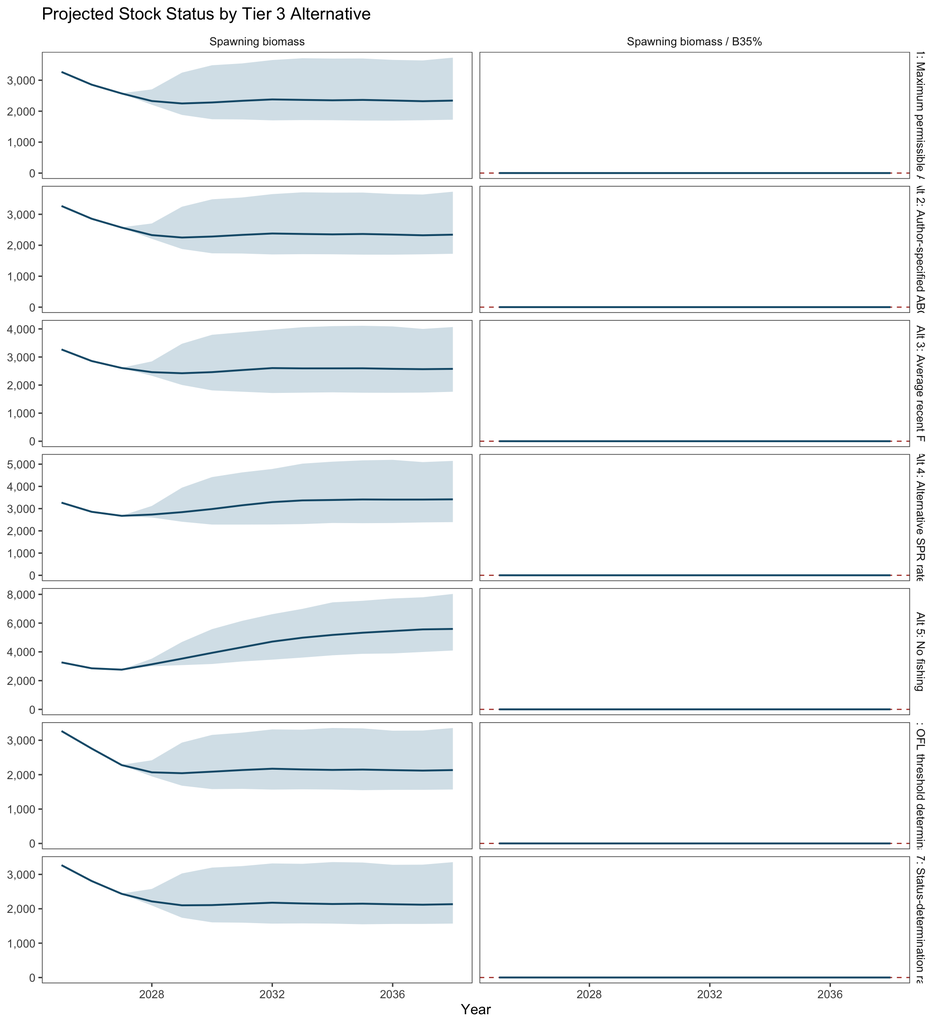

Figure 15: Projected spawning biomass and stock status under all seven Tier 3 alternatives. Lines are simulation medians and shaded bands span the 5th to 95th percentiles of the 1,000 SPM simulations. Spawning biomass is in thousand metric tons; the dashed line in the status panels marks B/B35% = 1.

```r
if (nrow(spmr_detail) > 0) {
  spmr_alt_names <- setNames(
    paste0("Alt ", spmr_alt_desc$Alternative, ": ", spmr_alt_desc$Name),
    spmr_alt_desc$Alternative
  )

  spmr_stock_plot <- spmr_detail |>
    mutate(
      scenario = factor(
        spmr_alt_names[as.character(Alt)],
        levels = unname(spmr_alt_names)
      ),
      `Spawning biomass` = SSB,
      `Spawning biomass / B35%` = SSB / B35
    ) |>
    select(scenario, Year, `Spawning biomass`, `Spawning biomass / B35%`) |>
    pivot_longer(
      c(`Spawning biomass`, `Spawning biomass / B35%`),
      names_to = "quantity",
      values_to = "value"
    ) |>
    group_by(scenario, Year, quantity) |>
    summarize(
      lower = quantile(value, 0.05, na.rm = TRUE),
      median = median(value, na.rm = TRUE),
      upper = quantile(value, 0.95, na.rm = TRUE),
      .groups = "drop"
    )

  ggplot(spmr_stock_plot, aes(x = Year, y = median)) +
    geom_hline(
      data = tibble(quantity = "Spawning biomass / B35%", reference = 1),
      aes(yintercept = reference),
      linetype = "dashed",
      color = "#b03a2e",
      linewidth = 0.45,
      inherit.aes = FALSE
    ) +
    geom_ribbon(aes(ymin = lower, ymax = upper), fill = "#2b7a9b", alpha = 0.22) +
    geom_line(color = "#155a78", linewidth = 0.75) +
    facet_grid(scenario ~ quantity, scales = "free_y") +
    scale_y_continuous(labels = scales::label_comma()) +
    labs(x = "Year", y = NULL, title = "Projected Stock Status by Tier 3 Alternative")
} else {
  plot.new()
  text(0.5, 0.5, "SPM projection results are unavailable.", cex = 0.9)
}
```

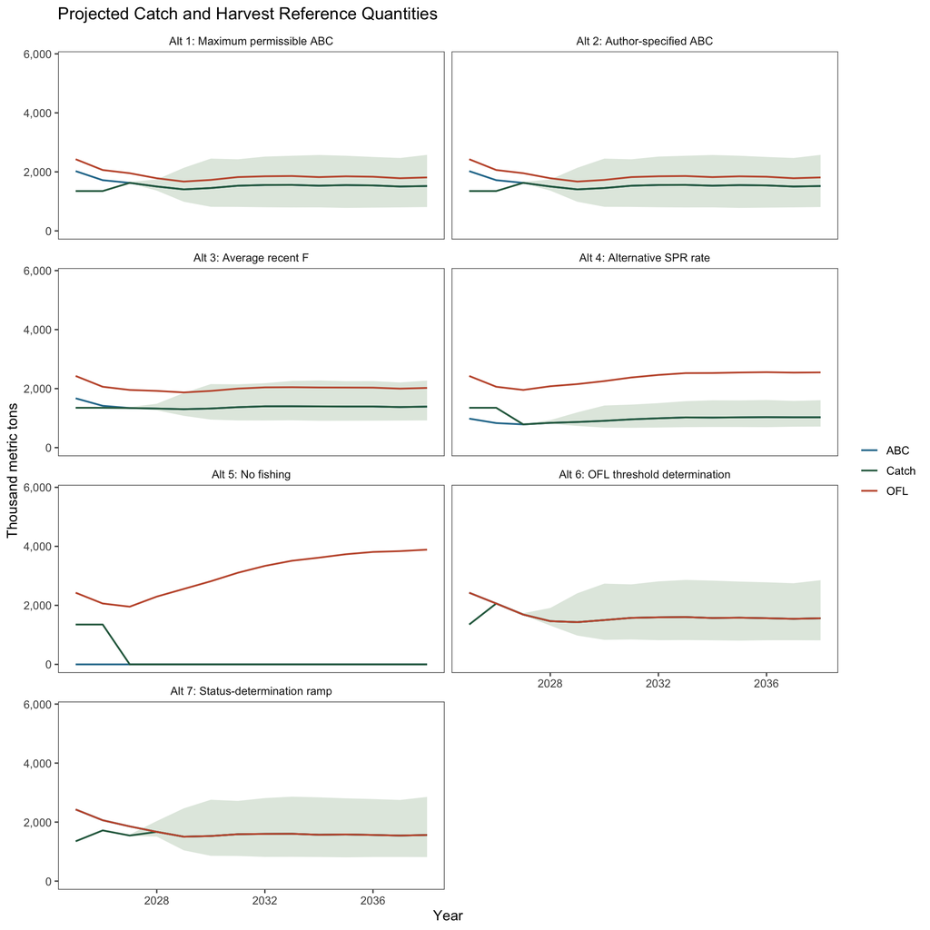

Figure 16: Projected catch and calculated ABC and OFL under all seven Tier 3 alternatives. Lines show simulation medians and the catch ribbons span the 5th to 95th percentiles of the 1,000 simulations. All quantities are thousand metric tons. ABC and OFL are reference quantities and need not equal realized catch under every alternative.

```r
if (nrow(spmr_detail) > 0) {
  spmr_removal_plot <- spmr_detail |>
    mutate(
      scenario = factor(
        spmr_alt_names[as.character(Alt)],
        levels = unname(spmr_alt_names)
      )
    ) |>
    select(scenario, Year, Catch, ABC, OFL) |>
    pivot_longer(c(Catch, ABC, OFL), names_to = "quantity", values_to = "value") |>
    group_by(scenario, Year, quantity) |>
    summarize(
      lower = quantile(value, 0.05, na.rm = TRUE),
      median = median(value, na.rm = TRUE),
      upper = quantile(value, 0.95, na.rm = TRUE),
      .groups = "drop"
    )

  removal_plot_max <- max(spmr_removal_plot$upper, na.rm = TRUE) * 1.03

  ggplot(spmr_removal_plot, aes(x = Year, y = median, color = quantity)) +
    geom_ribbon(
      data = filter(spmr_removal_plot, quantity == "Catch"),
      aes(ymin = lower, ymax = upper),
      fill = "#5b8c5a",
      color = NA,
      alpha = 0.2
    ) +
    geom_line(linewidth = 0.72) +
    facet_wrap(~scenario, ncol = 2) +
    scale_color_manual(values = c(Catch = "#2d6a4f", ABC = "#2b7a9b", OFL = "#c45a3c")) +
    scale_y_continuous(labels = scales::label_comma()) +
    coord_cartesian(ylim = c(0, removal_plot_max)) +
    labs(
      x = "Year",
      y = "Thousand metric tons",
      color = NULL,
      title = "Projected Catch and Harvest Reference Quantities"
    )
} else {
  plot.new()
  text(0.5, 0.5, "SPM projection results are unavailable.", cex = 0.9)
}
```

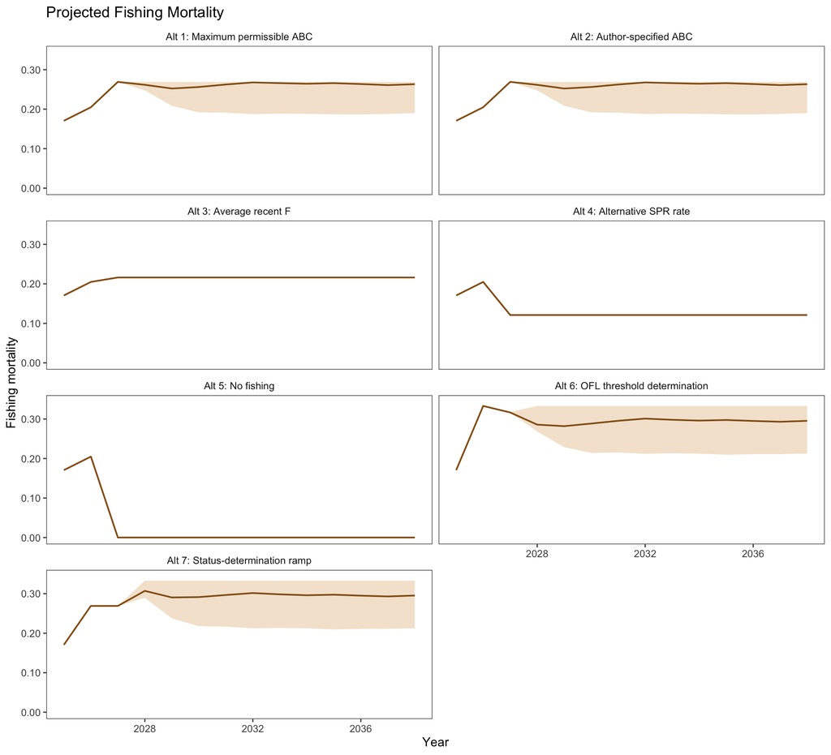

Figure 17: Projected fishing mortality under all seven Tier 3 alternatives. Lines are simulation medians and shaded bands span the 5th to 95th percentiles of the 1,000 simulations.

```r
if (nrow(spmr_detail) > 0) {
  spmr_f_plot <- spmr_detail |>
    mutate(
      scenario = factor(
        spmr_alt_names[as.character(Alt)],
        levels = unname(spmr_alt_names)
      )
    ) |>
    group_by(scenario, Year) |>
    summarize(
      lower = quantile(F, 0.05, na.rm = TRUE),
      median = median(F, na.rm = TRUE),
      upper = quantile(F, 0.95, na.rm = TRUE),
      .groups = "drop"
    )

  f_plot_max <- max(spmr_f_plot$upper, na.rm = TRUE) * 1.03

  ggplot(spmr_f_plot, aes(x = Year, y = median)) +
    geom_ribbon(aes(ymin = lower, ymax = upper), fill = "#d18b2c", alpha = 0.24) +
    geom_line(color = "#945f16", linewidth = 0.75) +
    facet_wrap(~scenario, ncol = 2) +
    scale_y_continuous(labels = scales::label_number(accuracy = 0.01)) +
    coord_cartesian(ylim = c(0, f_plot_max)) +
    labs(x = "Year", y = "Fishing mortality", title = "Projected Fishing Mortality")
} else {
  plot.new()
  text(0.5, 0.5, "SPM projection results are unavailable.", cex = 0.9)
}
```

The generated directory is intended as an input handoff. Running the projection model remains a separate step, for example `spmR::runSPM("analysis/output/spmR_projection", run = TRUE, engine = "admb")`, or `spmR::runSPM("analysis/output/spmR_projection", run = TRUE, engine = "rtmb")` for the current experimental RTMB path in `spmR`.

## 6.4 Diagnostics

```r
model_status_tbl <- tibble(
  metric = c(
    "RTMB output",
    "Report elements",
    "Parameters in taped object",
    "Initial objective",
    "Saved total likelihood",
    "ADMB bridge report",
    "ADMB bridge parameters",
    "Interpretation"
  ),
  value = c(
    params$model_file,
    as.character(length(names(rtmb_report))),
    as.character(length(obj$par)),
    sprintf("%.3f", obj$fn(obj$par)),
    sprintf("%.3f", as.numeric(rtmb_report$tot_like)),
    display_path(rtmb_metadata$admb_rep),
    display_path(rtmb_metadata$admb_par),
    "Saved report loads and the RTMB objective tapes successfully; full convergence diagnostics require a fitted optimizer object."
  )
)

model_status_tbl |>
  gt_report() |>
  tab_header(title = "Model Status Diagnostics")
```

Table 19: Summary diagnostics for the current saved RTMB-ADMB base model.

Model Status Diagnostics

| metric | value |
| --- | --- |
| RTMB output | analysis/output/base.rds |
| Report elements | 42 |
| Parameters in taped object | 1205 |
| Initial objective | 7940.716 |
| Saved total likelihood | 7940.716 |
| ADMB bridge report | [repo]/admb/runs/for_rtmb/pm.rep |
| ADMB bridge parameters | [repo]/admb/runs/for_rtmb/pm.par |
| Interpretation | Saved report loads and the RTMB objective tapes successfully; full convergence diagnostics require a fitted optimizer object. |

```r
nll_tbl <- tibble(
  component = c(
    "Catch",
    "BTS index",
    "ATS index",
    "ATS age-1 index",
    "CPUE",
    "AVO",
    "Fishery age composition",
    "BTS age composition",
    "ATS age composition",
    "Recruitment",
    "Fishing mortality penalty",
    "Selectivity penalty",
    "Weight-at-age",
    "Priors",
    "Total"
  ),
  value = c(
    rtmb_report$cat_like,
    rtmb_report$bts_like,
    rtmb_report$ats_like,
    rtmb_report$ats_age1_like,
    rtmb_report$cpue_like,
    rtmb_report$avo_like,
    rtmb_report$age_like[1],
    rtmb_report$age_like[2],
    rtmb_report$age_like[3],
    sum(rtmb_report$rec_like, na.rm = TRUE),
    rtmb_report$Fpen_like,
    sum(rtmb_report$sel_like, na.rm = TRUE) + sum(rtmb_report$sel_like_dev, na.rm = TRUE),
    rtmb_report$wt_like,
    sum(rtmb_report$Priors, na.rm = TRUE),
    rtmb_report$tot_like
  )
)

nll_tbl |>
  gt_report() |>
  fmt_number(columns = value, decimals = 3) |>
  tab_header(title = "Likelihood Diagnostics by Component")
```

Table 20: RTMB-ADMB likelihood diagnostics by component.

Likelihood Diagnostics by Component

| component | value |
| --- | --- |
| Catch | 2.739 |
| BTS index | 33.116 |
| ATS index | 9.330 |
| ATS age-1 index | 11.169 |
| CPUE | 1.080 |
| AVO | 9.076 |
| Fishery age composition | 160.983 |
| BTS age composition | 1,060.301 |
| ATS age composition | 30.240 |
| Recruitment | 34.590 |
| Fishing mortality penalty | 9.343 |
| Selectivity penalty | 213.559 |
| Weight-at-age | 6,344.865 |
| Priors | 20.138 |
| Total | 7,940.716 |

### 6.4.1 Retrospective Peels

The RTMB retrospective script was run for peel 0 (the full 2024 model) and nine retrospective peels terminating in 2023 through 2015. Each peel removes observations and weight-at-age inputs after its terminal year, shortens the corresponding annual parameter vectors, and starts from the preceding fitted peel. The BTS index has no 2020 observation in these inputs; the peeling code retains that data gap rather than treating 2020 as an observed BTS year.

```r
if (nrow(retro_diagnostics) > 0) {
  retro_diagnostics |>
    mutate(
      status = case_when(
        is.na(convergence) ~ "failed",
        convergence == 0 ~ "converged",
        TRUE ~ paste0("not converged: ", convergence)
      ),
      error = coalesce(error, "")
    ) |>
    select(
      peel, terminal_year, status, optimization_passes,
      objective, max_gradient, error
    ) |>
    gt_report() |>
    fmt_number(columns = any_of(c("objective", "max_gradient")), decimals = 3) |>
    tab_header(title = "RTMB Retrospective Peel Status")
} else {
  tibble(note = paste("No retrospective output found at", display_path(retro_file))) |>
    gt_report()
}
```

Table 21: RTMB retrospective run status for the full model (peel 0) and nine terminal-year peels. A convergence code of 0 indicates normal optimizer completion. Peels with an initial maximum gradient above 0.001 received one tighter restart; optimization passes records whether that restart was used.

RTMB Retrospective Peel Status

| peel | terminal_year | status | optimization_passes | objective | max_gradient | error |
| --- | --- | --- | --- | --- | --- | --- |
| 0 | 2024 | converged | 1 | 7,940.716 | 0.000 |  |
| 1 | 2023 | converged | 2 | 7,649.195 | 0.000 |  |
| 2 | 2022 | not converged: 1 | 2 | 6,338.443 | 0.000 |  |
| 3 | 2021 | converged | 2 | 4,772.580 | 0.000 |  |
| 4 | 2020 | converged | 1 | 2,899.038 | 0.001 |  |
| 5 | 2019 | converged | 1 | 1,776.829 | 0.001 |  |
| 6 | 2018 | converged | 1 | 418.117 | 0.001 |  |
| 7 | 2017 | converged | 1 | −1,017.122 | 0.001 |  |
| 8 | 2016 | converged | 1 | −2,680.698 | 0.001 |  |
| 9 | 2015 | converged | 1 | −4,330.470 | 0.001 |  |

```r
if (nrow(retro_mohn) > 0) {
  retro_mohn |>
    mutate(quantity = recode(quantity, SSB = "Spawning biomass")) |>
    gt_report() |>
    fmt_number(columns = rho, decimals = 3) |>
    cols_label(quantity = "Quantity", rho = "Mohn's rho", n_peels = "Peels") |>
    tab_header(title = "Nine-Peel Retrospective Summary")
}
```

Table 22: Mohn’s rho for spawning biomass and recruitment across nine retrospective peels. For each peel, the terminal-year estimate is compared with the estimate for the same year from the full model; rho is the mean relative difference. Positive values indicate that the truncated assessments estimate the quantity above the corresponding full-model estimate.

Nine-Peel Retrospective Summary

| Quantity | Mohn's rho | Peels |
| --- | --- | --- |
| Spawning biomass | 0.287 | 9 |
| Recruitment | 0.310 | 9 |

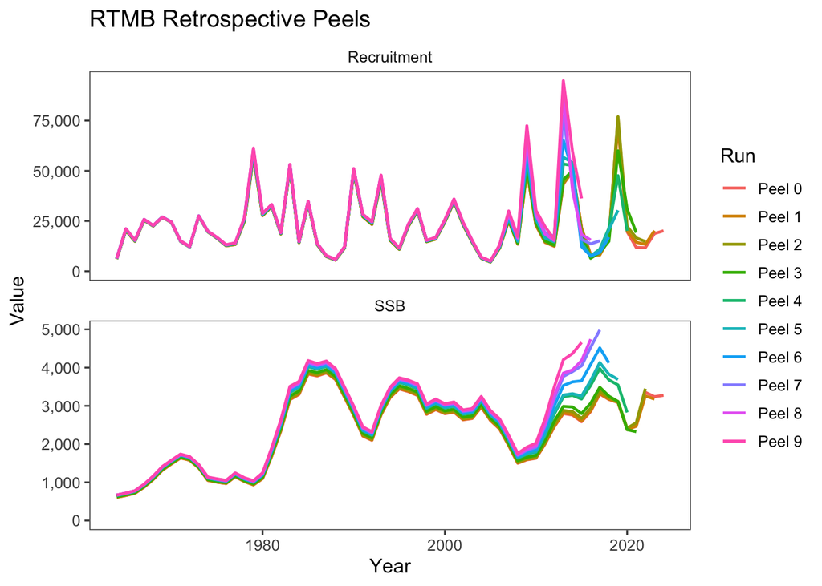

Figure 18: RTMB spawning-biomass and recruitment trajectories for the full model and nine retrospective peels. Each trajectory ends in its peel-specific terminal year.

```r
if (nrow(retro_series) > 0) {
  retro_series |>
    pivot_longer(c(SSB, Recruitment), names_to = "quantity", values_to = "value") |>
    mutate(peel = paste0("Peel ", peel)) |>
    ggplot(aes(x = year, y = value, color = peel, group = peel)) +
    geom_line(linewidth = 0.85) +
    facet_wrap(~quantity, scales = "free_y", ncol = 1) +
    scale_y_continuous(limits = c(0, NA), labels = scales::label_comma()) +
    labs(x = "Year", y = "Value", color = "Run", title = "RTMB Retrospective Peels")
} else {
  plot.new()
  text(
    0.5, 0.5,
    "No retrospective trajectory series was extractable from the current RTMB peel run.",
    cex = 0.9
  )
}
```

All nine peels completed and produced trajectory estimates. Nine of the ten fits including peel 0 ended with convergence code 0. Peel 2 ended its tighter restart with code 1, but its maximum gradient was 0.000126, below the report’s 0.001 gradient criterion. The largest maximum gradient across all fits was 0.0009. Mohn’s rho was 0.287 for spawning biomass and 0.310 for recruitment. Both are positive, and the spawning-biomass value is driven particularly by the deeper peels terminating in 2015–2020. These results indicate a substantial positive retrospective pattern and should be considered when evaluating stability and uncertainty.

# 7 Additional Bridge Diagnostics and Only-BTS Sensitivity

```r
tibble(
  item = c("Only BTS output", "Excluded likelihoods", "Convergence", "Objective", "Maximum gradient"),
  value = c(
    display_path(only_bts_file),
    if (!is.null(only_bts_metadata$excluded_likelihoods)) paste(only_bts_metadata$excluded_likelihoods, collapse = ", ") else NA_character_,
    if (!is.null(only_bts_saved$fit$convergence)) as.character(only_bts_saved$fit$convergence) else NA_character_,
    if (!is.null(only_bts_saved$fit$objective)) sprintf("%.3f", only_bts_saved$fit$objective) else NA_character_,
    if (!is.null(only_bts_metadata$max_gradient)) sprintf("%.6f", only_bts_metadata$max_gradient) else NA_character_
  )
) |>
  gt_report() |>
  tab_header(title = "Only BTS Sensitivity Run")
```

Table 23: Status for the Only BTS RTMB sensitivity model used in the bridge-comparison plot.

Only BTS Sensitivity Run

| item | value |
| --- | --- |
| Only BTS output | [repo]/analysis/output/only_bts.rds |
| Excluded likelihoods | NA |
| Convergence | NA |
| Objective | NA |
| Maximum gradient | NA |

```r
if (exists("pm") && !is.null(pm)) {
  bridge_tbl <- compare_max_pct(rtmb_report, pm, tolerance = 1e-6) |>
    arrange(desc(max_abs_pct_diff))
} else {
  bridge_tbl <- tibble(note = "ADMB bridge report was not available.")
}

bridge_tbl |>
  gt_report() |>
  fmt_number(columns = any_of(c("max_abs_diff", "max_abs_pct_diff", "cor")), decimals = 6) |>
  tab_header(title = "RTMB vs ADMB Bridge Comparison")
```

Table 24: Maximum absolute percent difference between the RTMB-ADMB base model and the ADMB bridge report for shared quantities.

RTMB vs ADMB Bridge Comparison

| variable | equal | length | max_abs_diff | max_abs_pct_diff | cor |
| --- | --- | --- | --- | --- | --- |
| sel_fsh | FALSE | 915 | 0.000005 | 0.000493 | 1.000000 |
| N | TRUE | 915 | 0.049919 | 0.000486 | 1.000000 |
| F | TRUE | 915 | 0.000000 | 0.000482 | 1.000000 |
| phat_fsh | TRUE | 900 | 0.000000 | 0.000482 | 1.000000 |
| sel_ats | FALSE | 465 | 0.000005 | 0.000471 | 1.000000 |
| phat_bts | FALSE | 630 | 0.000000 | 0.000469 | 1.000000 |
| obs_catch | FALSE | 61 | 0.005000 | 0.000458 | 1.000000 |
| eb_bts | TRUE | 42 | 0.048711 | 0.000456 | 1.000000 |
| SSB | FALSE | 61 | 0.004955 | 0.000447 | 1.000000 |
| phat_ats | TRUE | 285 | 0.004855 | 0.000443 | 1.000000 |
| pred_avo | FALSE | 18 | 0.000005 | 0.000409 | 1.000000 |
| sel_bts | TRUE | 645 | 0.000000 | 0.000400 | 1.000000 |
| pred_catch | FALSE | 61 | 0.004971 | 0.000383 | 1.000000 |
| sel_like_dev | FALSE | 3 | 0.000464 | 0.000375 | 1.000000 |
| age_like_offset | TRUE | 3 | 0.039496 | 0.000326 | 1.000000 |
| cpue_like | FALSE | 1 | 0.000003 | 0.000264 | NA |
| eb_ats | TRUE | 19 | 0.004863 | 0.000244 | 1.000000 |
| ats_age1_like | FALSE | 1 | 0.000024 | 0.000216 | NA |
| age_like | FALSE | 3 | 0.001047 | 0.000198 | 1.000000 |
| rec_like | FALSE | 7 | 0.000042 | 0.000196 | 1.000000 |
| phizero | FALSE | 1 | 0.000000 | 0.000189 | NA |
| wt_nll | TRUE | 4 | 0.004116 | 0.000167 | 1.000000 |
| Z | TRUE | 915 | 0.000000 | 0.000161 | 1.000000 |
| pred_cpue | TRUE | 12 | 0.004586 | 0.000146 | 1.000000 |
| sam_fsh | TRUE | 60 | 0.000499 | 0.000134 | 1.000000 |
| sel_like | FALSE | 3 | 0.000021 | 0.000123 | 1.000000 |
| S | TRUE | 915 | 0.000000 | 0.000123 | 1.000000 |
| Priors | FALSE | 4 | 0.000024 | 0.000118 | 1.000000 |
| wt_like | TRUE | 1 | 0.004805 | 0.000076 | NA |
| avgsel_like | TRUE | 1 | 0.000000 | 0.000061 | NA |
| cat_like | TRUE | 1 | 0.000002 | 0.000057 | NA |
| tot_like | TRUE | 1 | 0.004098 | 0.000052 | NA |
| steepness | TRUE | 1 | 0.000000 | 0.000051 | NA |
| bts_like | TRUE | 1 | 0.000014 | 0.000043 | NA |
| Bzero | TRUE | 1 | 0.002409 | 0.000039 | NA |
| ats_like | TRUE | 1 | 0.000002 | 0.000019 | NA |
| Fpen_like | TRUE | 1 | 0.000001 | 0.000015 | NA |
| avo_like | TRUE | 1 | 0.000000 | 0.000004 | NA |
| M | TRUE | 915 | 0.000000 | 0.000000 | 1.000000 |
| sam_bts | TRUE | 42 | 0.000000 | 0.000000 | 1.000000 |
| sam_ats | TRUE | 19 | 0.000000 | 0.000000 | 1.000000 |
| C | NA | NA | NA | NA | NA |

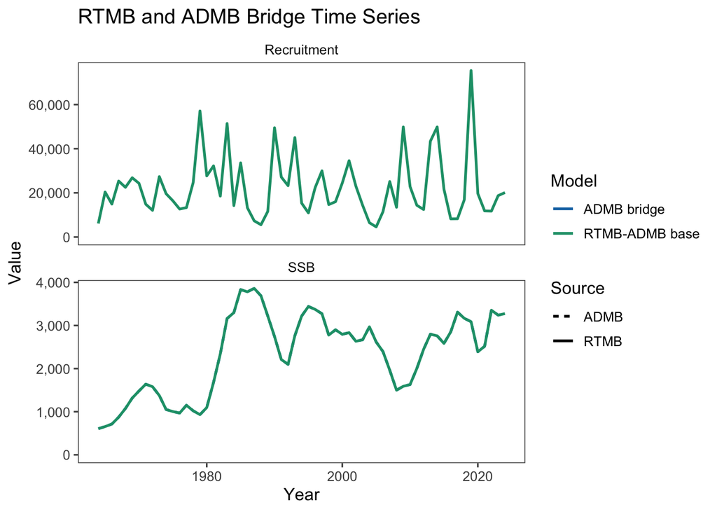

```r
if (nrow(admb_ts) > 0) {
  ggplot(diag_series, aes(x = year, y = value, color = model, linetype = source, group = model)) +
    geom_line(linewidth = 0.9) +
    facet_wrap(~quantity, scales = "free_y", ncol = 1) +
    scale_y_continuous(limits = c(0, NA), labels = scales::label_comma()) +
    scale_color_manual(values = c("RTMB-ADMB base" = "#1b9e77", "Only BTS" = "#d95f02", "ADMB bridge" = "#1f78b4")) +
    scale_linetype_manual(values = c("RTMB" = "solid", "ADMB" = "22")) +
    labs(x = "Year", y = "Value", color = "Model", linetype = "Source", title = "RTMB and ADMB Bridge Time Series")
} else {
  plot.new()
  text(0.5, 0.5, "ADMB bridge report not available.", cex = 1)
}
```

# 8 Reproducibility

```r
repro_tbl <- tibble(
  item = c(
    "Working directory",
    "Write output command",
    "Render command",
    "Default SparseNUTS command",
    "RTMB report object",
    "Default SparseNUTS output",
    "ADMB bridge run",
    "RTMB source"
  ),
  value = c(
    display_path(pollock_root),
    "Rscript R/write_output.R",
    "quarto render reporting/ebs_pollock_rtmb_ebswp_assessment.qmd",
    "quarto render reporting/ebs_pollock_rtmb_ebswp_assessment.qmd -P run_sparsenuts:true",
    display_path(model_file),
    display_path(sparsenuts_file),
    display_path(pollock_file("admb", "runs", "for_rtmb")),
    display_path(rtmb_root)
  )
)

repro_tbl |>
  gt_report() |>
  tab_header(title = "Reproducibility Checklist")
```

Table 25: Files and commands needed to reproduce the saved RTMB-ADMB output.

Reproducibility Checklist

| item | value |
| --- | --- |
| Working directory | [repo] |
| Write output command | Rscript R/write_output.R |
| Render command | quarto render reporting/ebs_pollock_rtmb_ebswp_assessment.qmd |
| Default SparseNUTS command | quarto render reporting/ebs_pollock_rtmb_ebswp_assessment.qmd -P run_sparsenuts:true |
| RTMB report object | [repo]/analysis/output/base.rds |
| Default SparseNUTS output | [repo]/analysis/output/sparsenuts/rtmb_ebswp_sparsenuts_default.rds |
| ADMB bridge run | [repo]/admb/runs/for_rtmb |
| RTMB source | [repo] |

# 9 Tables

```r
terminal_tbl <- tibble(
  metric = c("Total biomass", "Spawning biomass", "Recruitment", "Mean F", "Total F"),
  year = terminal_year,
  value = c(
    tail(ts_df$biomass, 1),
    tail(ts_df$ssb, 1),
    tail(ts_df$recruitment, 1),
    tail(ts_df$mean_f, 1),
    tail(ts_df$total_f, 1)
  )
)

terminal_tbl |>
  gt_report() |>
  fmt_number(columns = value, decimals = 3) |>
  tab_header(title = "Terminal-Year RTMB-ADMB Estimates")
```

Table 26: Key terminal-year values from the saved base RTMB-ADMB model.

Terminal-Year RTMB-ADMB Estimates

| metric | year | value |
| --- | --- | --- |
| Total biomass | 2024 | 12,342.805 |
| Spawning biomass | 2024 | 3,275.076 |
| Recruitment | 2024 | 20,124.325 |
| Mean F | 2024 | 0.163 |
| Total F | 2024 | 2.451 |

```r
scalar_tbl <- tibble(
  quantity = c("Bzero", "phizero", "steepness"),
  value = c(rtmb_report$Bzero, rtmb_report$phizero, rtmb_report$steepness)
)

scalar_tbl |>
  gt_report() |>
  fmt_number(columns = value, decimals = 6) |>
  tab_header(title = "Reported Scalar Quantities")
```

Reported Scalar Quantities

| quantity | value |
| --- | --- |
| Bzero | 6,109.557591 |
| phizero | 0.252161 |
| steepness | 0.619814 |

```r
naa_tbl <- bind_rows(
  tibble(year = first_year, age = ages, numbers = as.numeric(rtmb_report$N[1, ])),
  tibble(year = terminal_year, age = ages, numbers = as.numeric(rtmb_report$N[nrow(rtmb_report$N), ]))
)

naa_tbl |>
  gt_report() |>
  fmt_number(columns = numbers, decimals = 3) |>
  tab_header(title = "Numbers at Age")
```

Table 28: Initial and terminal estimated numbers-at-age from the saved RTMB-ADMB model.

Numbers at Age

| year | age | numbers |
| --- | --- | --- |
| 1964 | 1 | 6,093.588 |
| 1964 | 2 | 3,034.693 |
| 1964 | 3 | 1,836.726 |
| 1964 | 4 | 387.664 |
| 1964 | 5 | 180.083 |
| 1964 | 6 | 502.780 |
| 1964 | 7 | 228.531 |
| 1964 | 8 | 71.882 |
| 1964 | 9 | 45.103 |
| 1964 | 10 | 45.556 |
| 1964 | 11 | 45.851 |
| 1964 | 12 | 46.029 |
| 1964 | 13 | 45.940 |
| 1964 | 14 | 45.867 |
| 1964 | 15 | 45.792 |
| 2024 | 1 | 20,124.325 |
| 2024 | 2 | 7,620.235 |
| 2024 | 3 | 3,011.047 |
| 2024 | 4 | 2,157.719 |
| 2024 | 5 | 2,404.417 |
| 2024 | 6 | 5,327.892 |
| 2024 | 7 | 892.457 |
| 2024 | 8 | 282.786 |
| 2024 | 9 | 155.907 |
| 2024 | 10 | 182.451 |
| 2024 | 11 | 173.437 |
| 2024 | 12 | 71.354 |
| 2024 | 13 | 18.159 |
| 2024 | 14 | 14.398 |
| 2024 | 15 | 37.591 |

```r
f_at_age_tbl <- tibble(
  year = terminal_year,
  age = ages,
  f_at_age = as.numeric(rtmb_report$F[nrow(rtmb_report$F), ])
)

f_at_age_tbl |>
  gt_report() |>
  fmt_number(columns = f_at_age, decimals = 6) |>
  tab_header(title = "Terminal-Year Fishery F at Age")
```

Table 29: Estimated terminal-year fishery F-at-age from the saved RTMB-ADMB model.

Terminal-Year Fishery F at Age

| year | age | f_at_age |
| --- | --- | --- |
| 2024 | 1 | 0.000034 |
| 2024 | 2 | 0.010145 |
| 2024 | 3 | 0.040491 |
| 2024 | 4 | 0.121935 |
| 2024 | 5 | 0.234086 |
| 2024 | 6 | 0.179350 |
| 2024 | 7 | 0.187119 |
| 2024 | 8 | 0.204259 |
| 2024 | 9 | 0.212118 |
| 2024 | 10 | 0.212282 |
| 2024 | 11 | 0.211264 |
| 2024 | 12 | 0.209541 |
| 2024 | 13 | 0.209541 |
| 2024 | 14 | 0.209541 |
| 2024 | 15 | 0.209541 |

# 10 Appendix

## 10.1 Model Assumptions

```r
assumptions_tbl <- tibble(
  topic = c(
    "Bridge source",
    "Template",
    "Natural mortality",
    "BTS start year",
    "ATS start year",
    "Recruitment age",
    "Age-1 ATS index",
    "BTS biology likelihood",
    "ATS biology likelihood"
  ),
  setting = c(
    "ADMB bridge run in admb/runs/for_rtmb",
    "Physical bridge pm.tpl copy that intentionally differs from admb/source/pm.tpl",
    paste(round(data$natmort, 4), collapse = ", "),
    as.character(data$styr_bts),
    as.character(data$styr_ats),
    as.character(data$recage),
    as.character(data$use_age1_ats),
    as.character(data$do_bts_bio),
    as.character(data$do_ats_bio)
  )
)

assumptions_tbl |>
  gt_report() |>
  tab_header(title = "RTMB-ADMB Model Assumptions")
```

Table 30: Key model assumptions and fixed settings in the current RTMB-ADMB implementation.

RTMB-ADMB Model Assumptions

| topic | setting |
| --- | --- |
| Bridge source | ADMB bridge run in admb/runs/for_rtmb |
| Template | Physical bridge pm.tpl copy that intentionally differs from admb/source/pm.tpl |
| Natural mortality | 0.9, 0.45, 0.3, 0.3, 0.3, 0.3, 0.3, 0.3, 0.3, 0.3, 0.3, 0.3, 0.3, 0.3, 0.3 |
| BTS start year | 1982 |
| ATS start year | 1994 |
| Recruitment age | 1 |
| Age-1 ATS index | 1 |
| BTS biology likelihood | 1 |
| ATS biology likelihood | 1 |

## 10.2 SparseNUTS MCMC

This analysis applies the current `SparseNUTS` package to the **accepted base RTMB model** (`fishery_sel_form = 0`), not to the experimental Form 2 double-logistic model. The call leaves chains, cores, sampling iterations, warmup, initialization, and metric selection at the package defaults, but increases `adapt_delta` to 0.95 to reduce divergent transitions. The model name and `globals = list(data = model_data)` are also supplied. Exporting that RTMB data object lets the package rebuild the objective in its parallel R workers, so the package-default chains can run concurrently.

The completed fit is saved outside the rendered document. Every render reads that fit and rebuilds all MCMC tables and figures, preventing diagnostics from an older run from remaining in the report. The reproducible runner is `R/run_sparsenuts_default.R`.

```r
sample_dims <- if (!is.null(sparsenuts_fit$samples)) dim(sparsenuts_fit$samples) else NULL
draws_per_chain <- if (!is.null(sample_dims) && length(sample_dims) >= 2) sample_dims[1] else NA_integer_
chains <- if (!is.null(sample_dims) && length(sample_dims) >= 2) sample_dims[2] else NA_integer_
warmup <- sparsenuts_fit$warmup %||% NA_integer_
post_warmup <- if (is.finite(draws_per_chain) && is.finite(warmup)) draws_per_chain - warmup else NA_integer_
sparsenuts_run_metadata <- attr(sparsenuts_fit, "rtmb_ebswp_sparsenuts") %||% list()

sparsenuts_status <- tibble(
  metric = c(
    "Model configuration",
    "SparseNUTS installed",
    "SparseNUTS version",
    "SparseNUTS GitHub commit",
    "Default call",
    "Saved default output",
    "Output path",
    "Algorithm",
    "Metric",
    "Target acceptance probability",
    "Chains",
    "Parallel cores",
    "Execution mode",
    "Warmup iterations per chain",
    "Post-warmup samples per chain",
    "Elapsed time (minutes)",
    "Diagnostic object available",
    "Error"
  ),
  value = c(
    sparsenuts_run_metadata$model %||% "base RTMB model",
    as.character(sparsenuts_available),
    sparsenuts_run_metadata$package_version %||% if (sparsenuts_available) as.character(packageVersion("SparseNUTS")) else NA_character_,
    sparsenuts_run_metadata$package_remote_sha %||% NA_character_,
    "SparseNUTS::sample_snuts(obj, globals = list(data = model_data))",
    as.character(file.exists(sparsenuts_file)),
    display_path(sparsenuts_file),
    as.character(sparsenuts_fit$algorithm %||% NA_character_),
    as.character(sparsenuts_fit$metric %||% NA_character_),
    as.character(sparsenuts_run_metadata$adapt_delta %||% 0.95),
    as.character(chains),
    as.character(chains),
    sparsenuts_run_metadata$execution %||% "package-default parallel chains",
    as.character(warmup),
    as.character(post_warmup),
    if (is.null(sparsenuts_run_metadata$elapsed_seconds)) NA_character_ else sprintf("%.1f", sparsenuts_run_metadata$elapsed_seconds / 60),
    as.character(!is.null(sparsenuts_diagnostics)),
    sparsenuts_error %||% ""
  )
)

sparsenuts_status |>
  gt_report() |>
  tab_header(title = "SparseNUTS Default-Run Status")
```

Table 31: SparseNUTS default-run status for the RTMB-ADMB base model.

SparseNUTS Default-Run Status

| metric | value |
| --- | --- |
| Model configuration | accepted base RTMB model (fishery_sel_form = 0) |
| SparseNUTS installed | TRUE |
| SparseNUTS version | 1.0.2 |
| SparseNUTS GitHub commit | 2f3f1626219afce68fa2da0d884d4f2dca138117 |
| Default call | SparseNUTS::sample_snuts(obj, globals = list(data = model_data)) |
| Saved default output | TRUE |
| Output path | [repo]/analysis/output/sparsenuts/rtmb_ebswp_sparsenuts_default.rds |
| Algorithm | SNUTS |
| Metric | dense |
| Target acceptance probability | 0.95 |
| Chains | 4 |
| Parallel cores | 4 |
| Execution mode | parallel chains using package-default chains and cores |
| Warmup iterations per chain | 150 |
| Post-warmup samples per chain | 1000 |
| Elapsed time (minutes) | 2.8 |
| Diagnostic object available | TRUE |
| Error |  |

```r
if (!is.null(sparsenuts_fit) && !is.null(sparsenuts_fit$monitor)) {
  diag_values <- sparsenuts_diagnostics %||% data.frame(
    perc_divergent = NA_real_, perc_treedepth = NA_real_,
    num_below_threshold = NA_real_
  )
  post_warmup_total <- chains * post_warmup
  divergence_percent <- diag_values$perc_divergent[1] %||% NA_real_
  warmup_divergences <- sum(vapply(
    sparsenuts_fit$sampler_params,
    function(x) sum(x[seq_len(warmup), "divergent__"]),
    numeric(1)
  ))
  sampling_divergences <- round(post_warmup_total * divergence_percent / 100)
  diag_tbl <- tibble(
    diagnostic = c(
      "Post-warmup draws", "Warmup divergences", "Post-warmup divergences",
      "Post-warmup divergent transitions (%)",
      "Maximum R-hat", "Minimum bulk ESS", "Median bulk ESS",
      "Minimum tail ESS", "Maximum-treedepth transitions (%)"
    ),
    value = c(
      post_warmup_total,
      warmup_divergences,
      sampling_divergences,
      divergence_percent,
      max(sparsenuts_fit$monitor$rhat, na.rm = TRUE),
      min(sparsenuts_fit$monitor$ess_bulk, na.rm = TRUE),
      median(sparsenuts_fit$monitor$ess_bulk, na.rm = TRUE),
      min(sparsenuts_fit$monitor$ess_tail, na.rm = TRUE),
      diag_values$perc_treedepth[1] %||% NA_real_
    )
  )
} else {
  diag_tbl <- tibble(
    diagnostic = "status",
    value = "No SparseNUTS diagnostics are available. Render with run_sparsenuts: true to create the default run."
  )
}

diag_tbl |>
  gt_report() |>
  fmt_number(columns = value, decimals = 3) |>
  tab_header(title = "SparseNUTS Base-Model Diagnostics")
```

Table 32: Diagnostics for the current package-default SparseNUTS run of the base RTMB model. R-hat values near 1 and larger effective sample sizes indicate good between-chain mixing. Divergences identify transitions that did not adequately explore the posterior geometry and should be resolved before using the draws for final inference.

SparseNUTS Base-Model Diagnostics

| diagnostic | value |
| --- | --- |
| Post-warmup draws | 4,000.000 |
| Warmup divergences | 7.000 |
| Post-warmup divergences | 1.000 |
| Post-warmup divergent transitions (%) | 0.030 |
| Maximum R-hat | 1.006 |
| Minimum bulk ESS | 1,569.026 |
| Median bulk ESS | 5,522.672 |
| Minimum tail ESS | 1,126.933 |
| Maximum-treedepth transitions (%) | 0.000 |

With `adapt_delta = 0.95`, the run produced 7 divergences during adaptation and **1 divergences among the 4,000 retained transitions**. Maximum R-hat was 1.006, and minimum bulk effective sample size was 1,569. The chain-mixing statistics are good, but 1 retained divergence remains; its location should be checked before treating the posterior as final. Substantive posterior checks and comparison with deterministic uncertainty remain appropriate before using the draws in assessment decisions.

```r
if (length(slow_parameter_names) > 0) {
  sparsenuts_fit$monitor |>
    filter(variable %in% slow_parameter_names) |>
    mutate(variable = factor(variable, levels = slow_parameter_names)) |>
    arrange(variable) |>
    select(variable, mean, sd, rhat, ess_bulk, ess_tail) |>
    gt_report() |>
    fmt_number(columns = c(mean, sd, rhat, ess_bulk, ess_tail), decimals = 3) |>
    tab_header(title = "Slow-Order Diagnostic Parameters")
} else {
  tibble(note = "No SparseNUTS parameter diagnostics available.") |>
    gt_report() |>
    tab_header(title = "Slow-Order Diagnostic Parameters")
}
```

Slow-Order Diagnostic Parameters

| variable | mean | sd | rhat | ess_bulk | ess_tail |
| --- | --- | --- | --- | --- | --- |
| sel_devs_fsh[225] | −0.099 | 0.255 | 1.006 | 5,771.870 | 2,445.864 |
| sel_devs_ats[127] | 0.553 | 0.272 | 1.006 | 5,117.029 | 3,060.521 |
| sel_devs_fsh[487] | 0.113 | 0.325 | 1.006 | 5,036.415 | 3,220.065 |
| sel_devs_fsh[294] | 0.707 | 0.269 | 1.006 | 5,113.316 | 2,902.891 |
| sel_devs_fsh[175] | −0.311 | 0.273 | 1.005 | 5,514.160 | 2,740.210 |
| sel_devs_ats[38] | 0.565 | 0.272 | 1.005 | 5,434.020 | 3,089.121 |
| log_F_devs[25] | −2.069 | 0.127 | 1.005 | 5,030.690 | 2,992.013 |
| sel_devs_fsh[661] | 0.063 | 0.296 | 1.005 | 5,495.144 | 3,331.309 |
| log_initdevs[6] | 5.140 | 0.998 | 1.005 | 1,855.843 | 1,435.172 |
| log_rec_devs[52] | 10.004 | 0.058 | 1.005 | 4,527.037 | 2,638.703 |
| sel_devs_fsh[146] | −0.022 | 0.275 | 1.004 | 5,566.546 | 2,697.688 |
| sel_devs_fsh[697] | 0.083 | 0.284 | 1.004 | 5,489.119 | 2,978.478 |

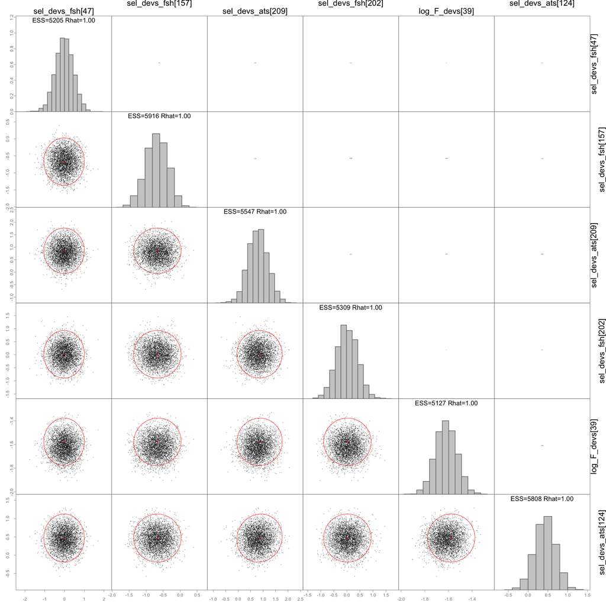

```r
if (file.exists(sparsenuts_figures$pairs_slow)) {
  knitr::include_graphics(sparsenuts_figures$pairs_slow)
}
```

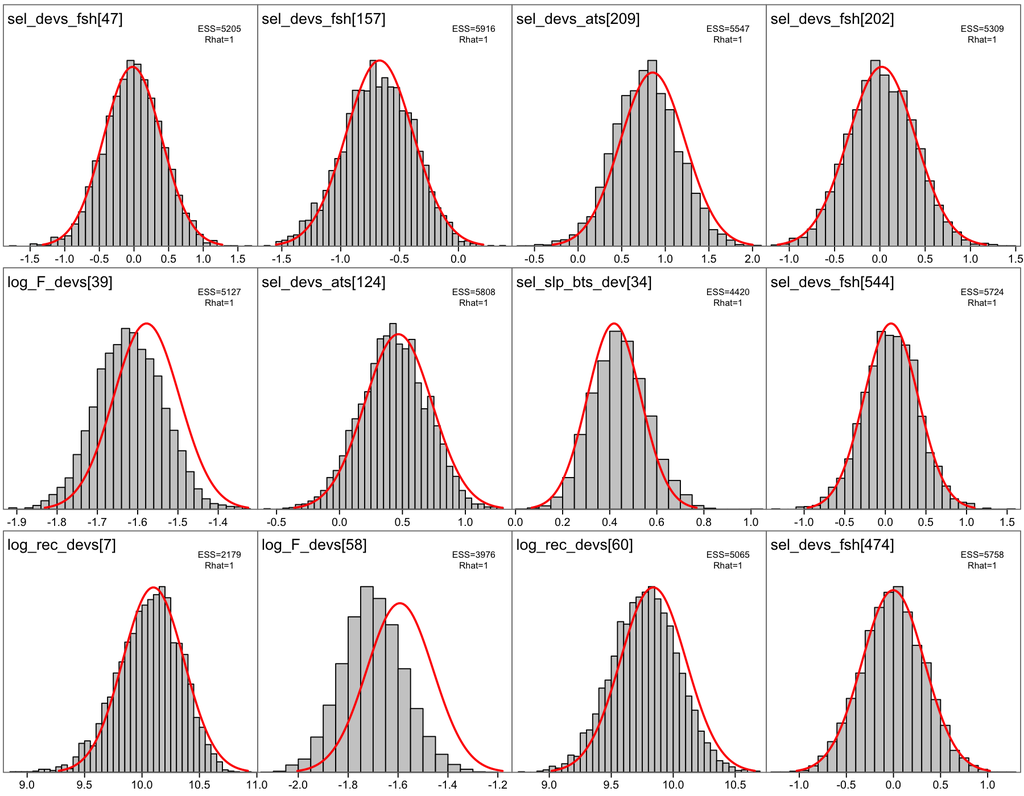

Figure 21: SparseNUTS::plot_marginals output from the default RTMB-ADMB SparseNUTS run using `order = 'slow'` for the selected parameter set.

```r
if (file.exists(sparsenuts_figures$marginals_slow)) {
  knitr::include_graphics(sparsenuts_figures$marginals_slow)
}
```

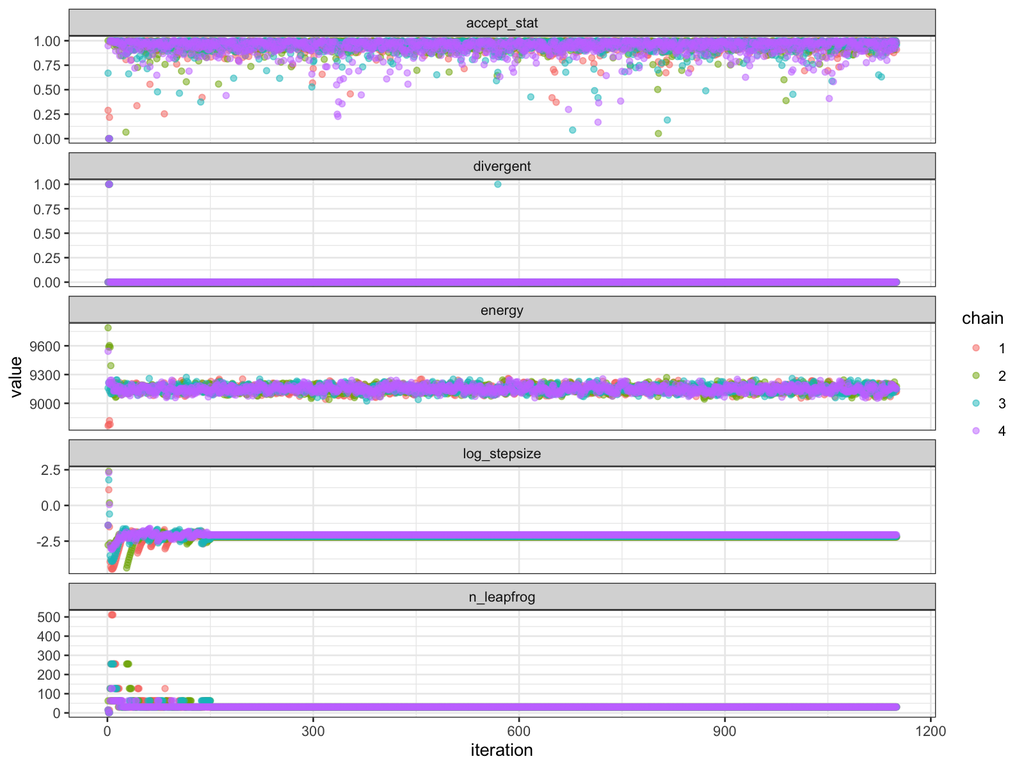

Figure 22: SparseNUTS sampler-parameter diagnostics from the default RTMB-ADMB run.

```r
if (file.exists(sparsenuts_figures$sampler)) {
  knitr::include_graphics(sparsenuts_figures$sampler)
}
```

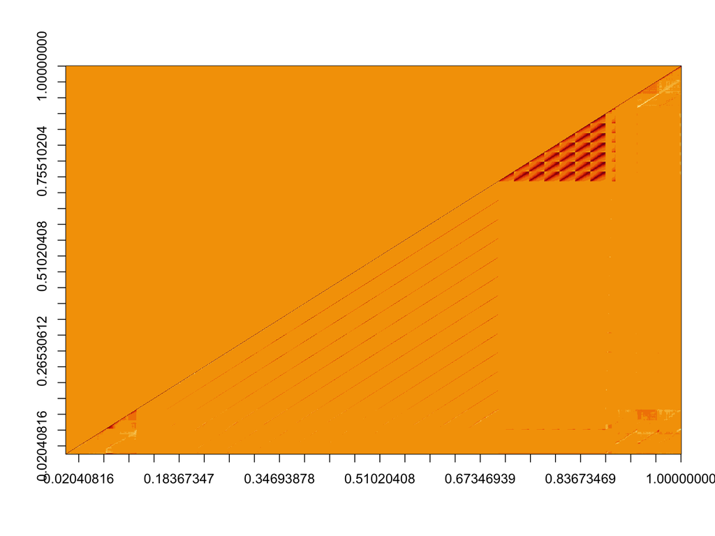

Figure 23: SparseNUTS::plot_Q output from the default RTMB-ADMB run.

```r
if (file.exists(sparsenuts_figures$q)) {
  knitr::include_graphics(sparsenuts_figures$q)
}
```

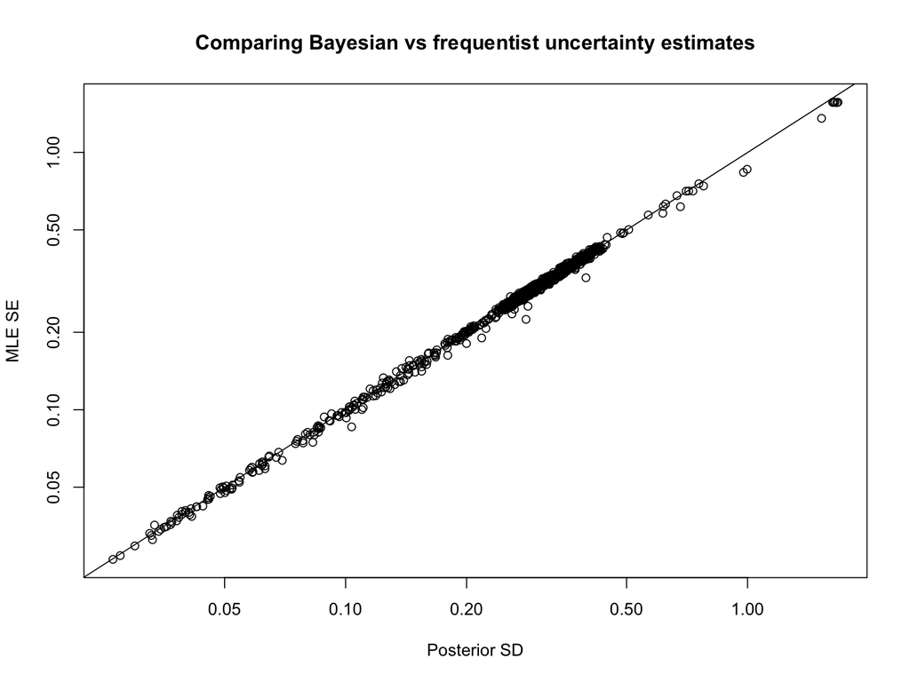

Figure 24: SparseNUTS::plot_uncertainties output from the default RTMB-ADMB run.

```r
if (file.exists(sparsenuts_figures$uncertainties)) {
  knitr::include_graphics(sparsenuts_figures$uncertainties)
}
```

## 10.3 Data Tables

```r
waa_tbl <- tibble(
  year = terminal_year,
  age = ages,
  weight = as.numeric(data$wt_ssb[nrow(data$wt_ssb), ])
)

waa_tbl |>
  gt_report() |>
  fmt_number(columns = weight, decimals = 5) |>
  tab_header(title = "Terminal-Year Spawning Weight at Age")
```

Table 34: Input spawning weight-at-age values used in the terminal model year.

Terminal-Year Spawning Weight at Age

| year | age | weight |
| --- | --- | --- |
| 2024 | 1 | 0.08488 |
| 2024 | 2 | 0.19587 |
| 2024 | 3 | 0.32155 |
| 2024 | 4 | 0.53394 |
| 2024 | 5 | 0.62078 |
| 2024 | 6 | 0.70710 |
| 2024 | 7 | 0.82220 |
| 2024 | 8 | 0.94591 |
| 2024 | 9 | 1.05120 |
| 2024 | 10 | 1.11338 |
| 2024 | 11 | 1.17845 |
| 2024 | 12 | 1.29002 |
| 2024 | 13 | 1.33154 |
| 2024 | 14 | 1.36674 |
| 2024 | 15 | 1.41524 |

```r
maturity_tbl <- tibble(
  age = ages,
  maturity = as.numeric(data$p_mature)
)

maturity_tbl |>
  gt_report() |>
  fmt_number(columns = maturity, decimals = 5) |>
  tab_header(title = "Maturity at Age")
```

Table 35: Input maturity-at-age schedule used in the RTMB-ADMB model.

Maturity at Age

| age | maturity |
| --- | --- |
| 1 | 0.00000 |
| 2 | 0.00800 |
| 3 | 0.28900 |
| 4 | 0.64100 |
| 5 | 0.84200 |
| 6 | 0.90100 |
| 7 | 0.94700 |
| 8 | 0.96300 |
| 9 | 0.97000 |
| 10 | 1.00000 |
| 11 | 1.00000 |
| 12 | 1.00000 |
| 13 | 1.00000 |
| 14 | 1.00000 |
| 15 | 1.00000 |

## 10.4 Report Inventory

```r
report_inventory <- tibble(
  element = names(rtmb_report),
  class = vapply(rtmb_report, function(x) paste(class(x), collapse = "/"), character(1)),
  length = vapply(rtmb_report, length, integer(1)),
  dimensions = vapply(rtmb_report, function(x) {
    d <- dim(x)
    if (is.null(d)) "" else paste(d, collapse = " x ")
  }, character(1))
)

report_inventory |>
  gt_report() |>
  tab_header(title = "Saved RTMB Report Inventory")
```

Table 36: Inventory of named elements in the saved RTMB report object.

Saved RTMB Report Inventory

| element | class | length | dimensions |
| --- | --- | --- | --- |
| N | matrix/array | 915 | 61 x 15 |
| Z | matrix/array | 915 | 61 x 15 |
| F | matrix/array | 915 | 61 x 15 |
| M | matrix/array | 915 | 61 x 15 |
| S | matrix/array | 915 | 61 x 15 |
| C | function | 1 |  |
| pred_catch | numeric | 61 |  |
| obs_catch | numeric | 61 |  |
| SSB | numeric | 61 |  |
| phizero | numeric | 1 |  |
| Bzero | numeric | 1 |  |
| steepness | numeric | 1 |  |
| pred_cpue | numeric | 12 |  |
| pred_avo | numeric | 18 |  |
| eb_bts | numeric | 42 |  |
| eb_ats | numeric | 19 |  |
| sel_fsh | matrix/array | 915 | 61 x 15 |
| sel_bts | matrix/array | 645 | 43 x 15 |
| sel_ats | matrix/array | 465 | 31 x 15 |
| sam_fsh | numeric | 60 |  |
| sam_bts | numeric | 42 |  |
| sam_ats | numeric | 19 |  |
| phat_fsh | matrix/array | 900 | 60 x 15 |
| phat_bts | matrix/array | 630 | 42 x 15 |
| phat_ats | matrix/array | 285 | 19 x 15 |
| age_like | numeric | 3 |  |
| age_like_offset | numeric | 3 |  |
| cat_like | numeric | 1 |  |
| bts_like | matrix/array | 1 | 1 x 1 |
| ats_like | numeric | 1 |  |
| ats_age1_like | numeric | 1 |  |
| cpue_like | numeric | 1 |  |
| avo_like | numeric | 1 |  |
| avgsel_like | numeric | 1 |  |
| wt_nll | numeric | 4 |  |
| wt_like | numeric | 1 |  |
| rec_like | numeric | 7 |  |
| Fpen_like | numeric | 1 |  |
| sel_like | numeric | 3 |  |
| sel_like_dev | numeric | 3 |  |
| Priors | numeric | 4 |  |
| tot_like | numeric | 1 |  |

# 11 Notes

This report is intended to support model-port debugging and bridge diagnostics. It does not replace the parent cross-platform comparison documents in `doc/`, and it should not be interpreted as a final assessment report without additional convergence, estimability, retrospective, and sensitivity diagnostics.